# 4_Transformacion_dplyr

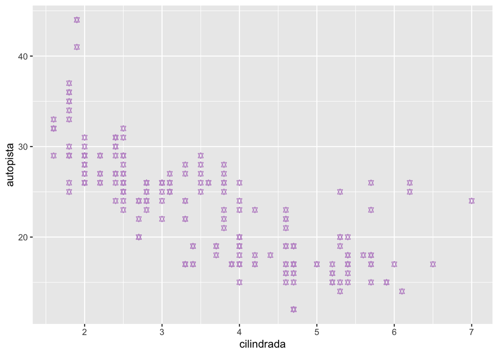

```r
ggplot(data = millas) +
 geom_point(mapping = aes(x = cilindrada, y = autopista), shape=11, color = "#c093cc", fill="yellow")
```

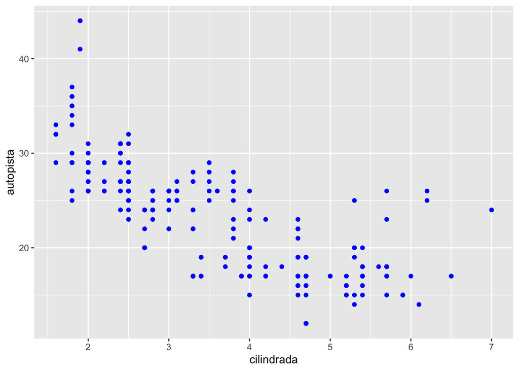

```r
 ggplot(data = millas) +
   geom_point(mapping = aes(x = cilindrada, y = autopista), color = "blue")
```

```r
ggsave("cilindro_milla.jpg") #. png, .tiff
millas
```

```
## # A tibble: 234 × 11
##    fabricante modelo     cilindrada  anio cilindros transmision traccion ciudad
##    <chr>      <chr>           <dbl> <int>     <int> <chr>       <chr>     <int>
##  1 audi       a4                1.8  1999         4 auto(l5)    d            18
##  2 audi       a4                1.8  1999         4 manual(m5)  d            21
##  3 audi       a4                2    2008         4 manual(m6)  d            20
##  4 audi       a4                2    2008         4 auto(av)    d            21
##  5 audi       a4                2.8  1999         6 auto(l5)    d            16
##  6 audi       a4                2.8  1999         6 manual(m5)  d            18
##  7 audi       a4                3.1  2008         6 auto(av)    d            18
##  8 audi       a4 quattro        1.8  1999         4 manual(m5)  4            18
##  9 audi       a4 quattro        1.8  1999         4 auto(l5)    4            16
## 10 audi       a4 quattro        2    2008         4 manual(m6)  4            20
## # ℹ 224 more rows
## # ℹ 3 more variables: autopista <int>, combustible <chr>, clase <chr>
```

Ejercicio para someter:

1. baja el paquete “ggversa”
2. activar el paquete “ggversa”
3. mirar las variables del archivo en este paquete que se llama “Anolis”
4. haga un gráfico que incluye lo siguiente
   1. en el eje de x = el SVL. que es el tamaño del lagarto del hocico a la cloaca y en la variable de “TAIL” en el eje de y.
2. selecciona la variable “SEX_AGE” para color
3. selecciona la función correcta para que cada “SEX_AGE” tenga su proprio gráfico
4. salva el gráfico en .png o .jpg
5. subir el gráfico aquí

```r
library(ggversa)
head(Anolis)
```

```
## # A tibble: 6 × 15
##   STUDY      Survey_Site      LOCATION TIME  DATE  SEASON SPECIES SEX_AGE HEIGHT
##   <chr>      <chr>            <chr>    <tim> <chr> <chr>  <chr>   <chr>    <dbl>
## 1 Mark/recap North Tower      El Verde 10:46 3/13… dry    Anolis… Female     0
## 2 Mark/recap Woods walkway t… El Verde 10:15 2/20… dry    Anolis… Juvenil    0
## 3 Mark/recap Woods walkway t… El Verde 11:15 2/21… dry    Anolis… Male       0
## 4 Mark/recap North Tower      El Verde 11:06 3/16… dry    Anolis… Juvenil    0.3
## 5 Mark/recap North Tower      El Verde 12:31 3/11… dry    Anolis… Male       0.3
## 6 Mark/recap North Tower      El Verde 01:00 3/9/… dry    Anolis… Female     0.4
## # ℹ 6 more variables: DISTANCE_FROM_CENTERLINE <dbl>, PERCH_SUBSTRATE <chr>,
## #   PERCH_DIAMETER <int>, WEIGHT <dbl>, SVL <dbl>, TAIL <dbl>
```

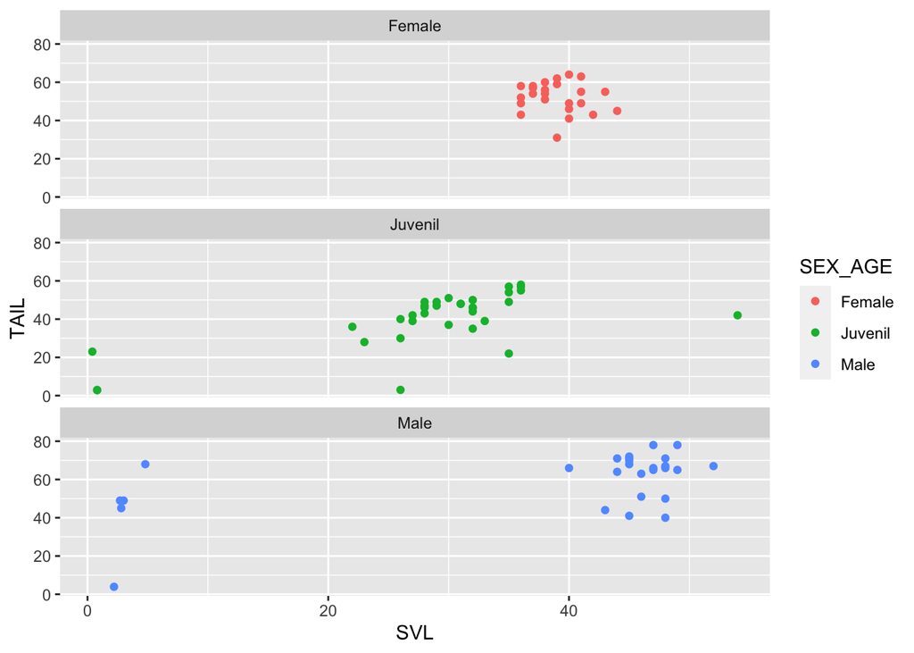

```r
ggplot(data = Anolis) +
  geom_point(mapping = aes(x = SVL, y = TAIL, color=SEX_AGE))+
  facet_wrap(~SEX_AGE, ncol=1)
```

```r
# izquierda
ggplot(data = millas) +
  geom_point(mapping = aes(x = cilindrada, y = autopista))
```

[output not shown]

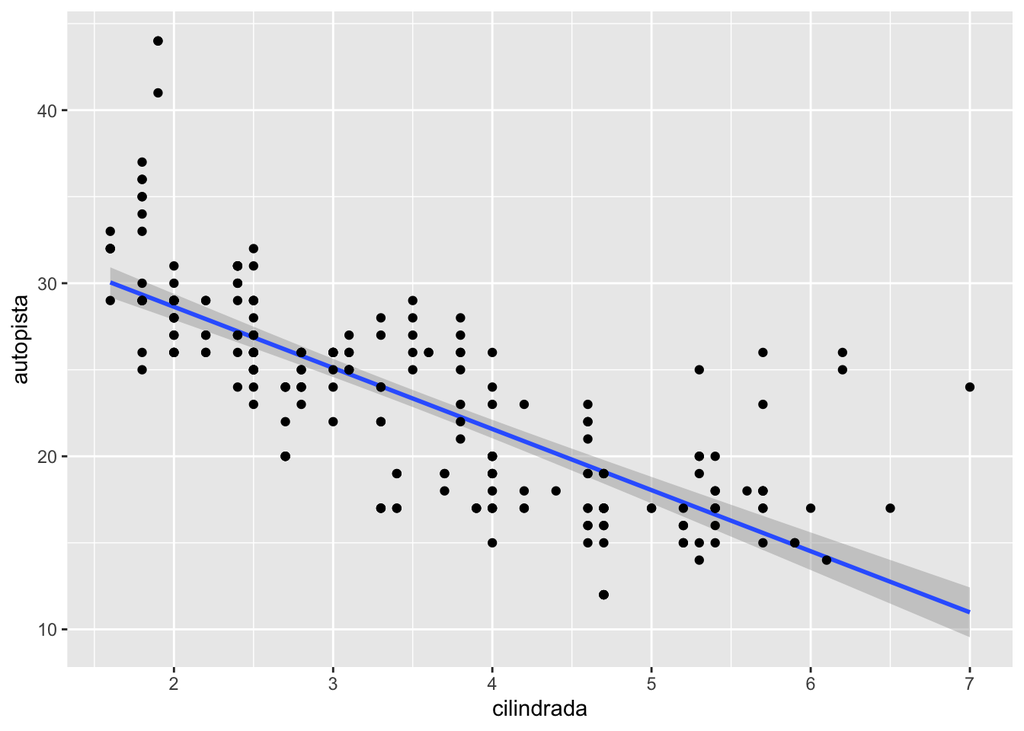

```r
# derecha   LOESS
ggplot(data = millas) +
  geom_smooth(method=lm,mapping = aes(x = cilindrada, y = autopista))+  # y = mx+b
  geom_point( mapping = aes(x = cilindrada, y = autopista))
```

```r
names(millas)
```

```
##  [1] "fabricante"  "modelo"      "cilindrada"  "anio"        "cilindros"
##  [6] "transmision" "traccion"    "ciudad"      "autopista"   "combustible"
## [11] "clase"
```

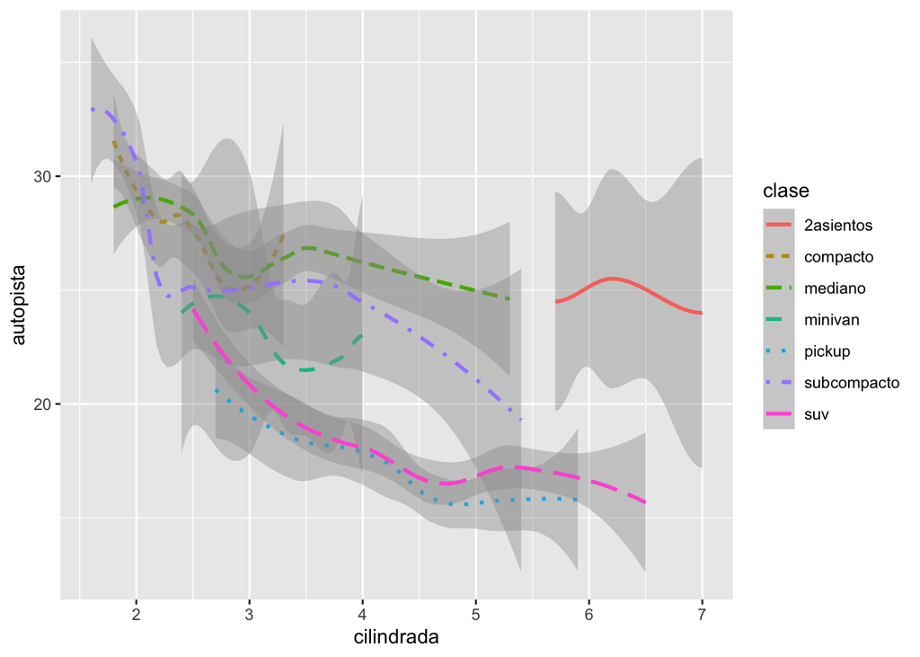

```r
ggplot(data = millas) +
  geom_smooth(mapping = aes(x = cilindrada, y = autopista, linetype = clase, colour=clase))
```

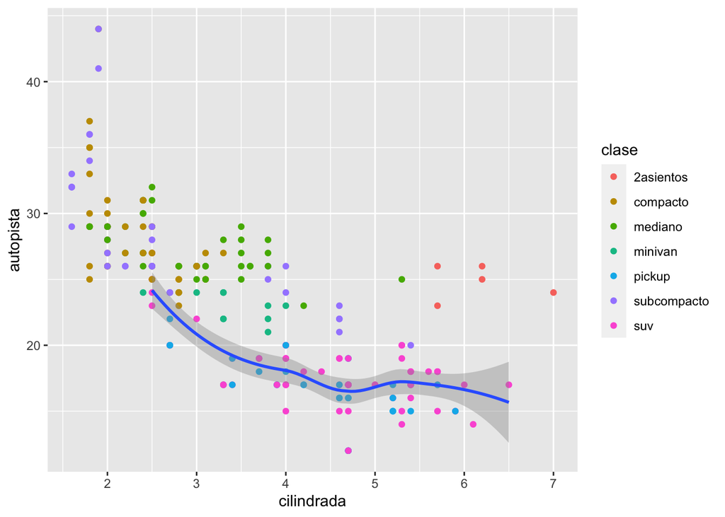

```r
ggplot(data = millas, mapping = aes(x = cilindrada, y = autopista)) +
  geom_point(mapping = aes(color = clase)) +
  geom_smooth(data = filter(millas, clase == "suv"), se =TRUE)
```

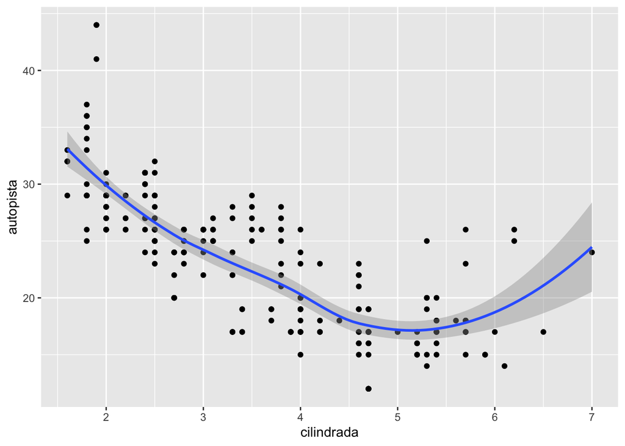

```r
ggplot(data = millas, mapping = aes(x = cilindrada, y = autopista)) +
  geom_point() +
  geom_smooth()
```

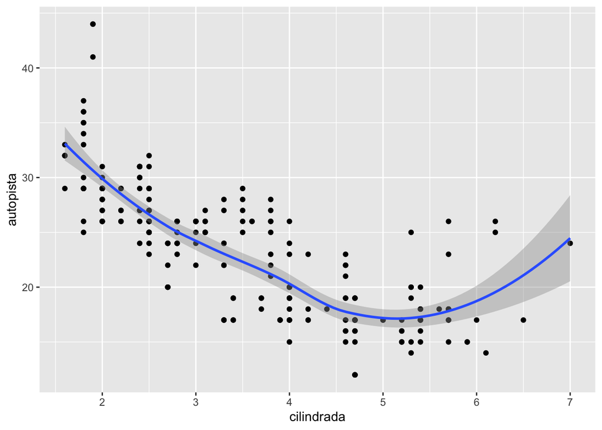

```r
ggplot() +
  geom_point(data = millas, mapping = aes(x = cilindrada, y = autopista)) +
  geom_smooth(data = millas, mapping = aes(x = cilindrada, y = autopista))
```

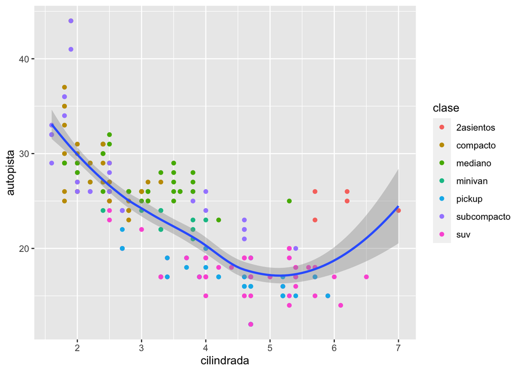

```r
ggplot(data = millas, mapping = aes(x = cilindrada, y = autopista)) +
  geom_point(mapping = aes(color = clase)) +
  geom_smooth()
```

## Transformación estadística

```r
head(diamantes)
```

```
## # A tibble: 6 × 10
##   precio quilate corte     color claridad profundidad tabla     x     y     z
##    <int>   <dbl> <ord>     <ord> <ord>          <dbl> <dbl> <dbl> <dbl> <dbl>
## 1    326    0.23 Ideal     E     SI2             61.5    55  3.95  3.98  2.43
## 2    326    0.21 Premium   E     SI1             59.8    61  3.89  3.84  2.31
## 3    327    0.23 Bueno     E     VS1             56.9    65  4.05  4.07  2.31
## 4    334    0.29 Premium   I     VS2             62.4    58  4.2   4.23  2.63
## 5    335    0.31 Bueno     J     SI2             63.3    58  4.34  4.35  2.75
## 6    336    0.24 Muy bueno J     VVS2            62.8    57  3.94  3.96  2.48
```

```r
nrow(diamantes)
```

```
## [1] 53940
```

```r
ncol(diamantes)
```

```
## [1] 10
```

```r
dim(diamantes)
```

```
## [1] 53940    10
```

```r
max(diamantes$precio)
```

```
## [1] 18823
```

```r
min(diamantes$precio)
```

```
## [1] 326
```

```r
unique(diamantes$corte)
```

```
## [1] Ideal     Premium   Bueno     Muy bueno Regular
## Levels: Regular < Bueno < Muy bueno < Premium < Ideal
```

```r
#diamantes$corte
#diamantes$precio
```

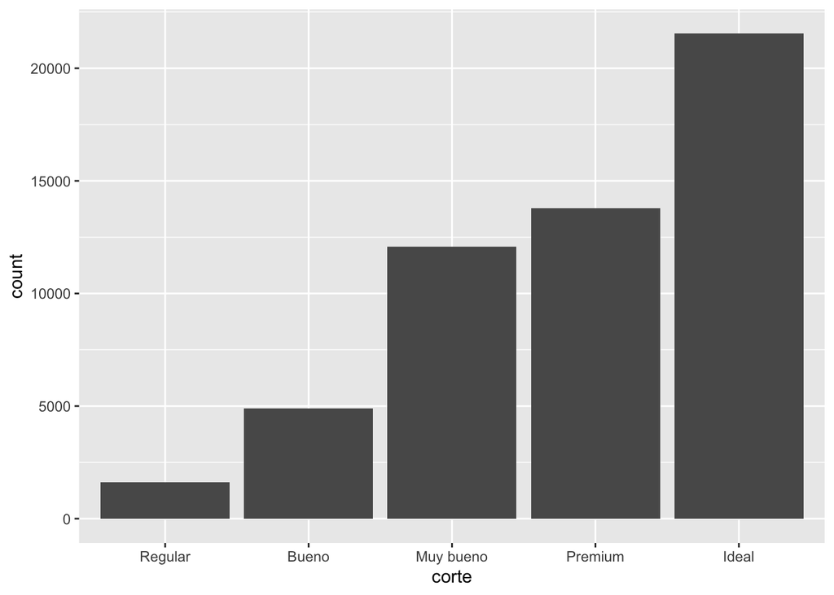

```r
ggplot(data = diamantes) +
  geom_bar(mapping = aes(x = corte))
```

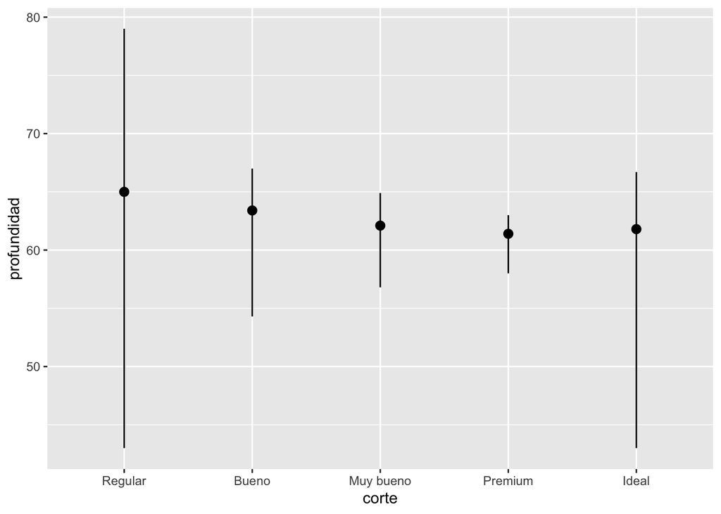

```r
ggplot(data = diamantes) +
  stat_summary(
    mapping = aes(x = corte, y = profundidad),
    fun.min = min,
    fun.max = max,
    fun = median
  )
```

```r
x=c(1:100, NA)
x
```

```
##   [1]   1   2   3   4   5   6   7   8   9  10  11  12  13  14  15  16  17  18
##  [19]  19  20  21  22  23  24  25  26  27  28  29  30  31  32  33  34  35  36
##  [37]  37  38  39  40  41  42  43  44  45  46  47  48  49  50  51  52  53  54
##  [55]  55  56  57  58  59  60  61  62  63  64  65  66  67  68  69  70  71  72
##  [73]  73  74  75  76  77  78  79  80  81  82  83  84  85  86  87  88  89  90
##  [91]  91  92  93  94  95  96  97  98  99 100  NA
```

```r
mean(x, na.rm=TRUE)
```

```
## [1] 50.5
```

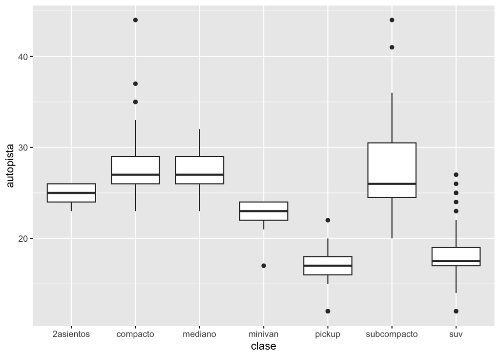

```r
ggplot(data = millas, mapping = aes(x = clase, y = autopista)) +
  geom_boxplot()
```

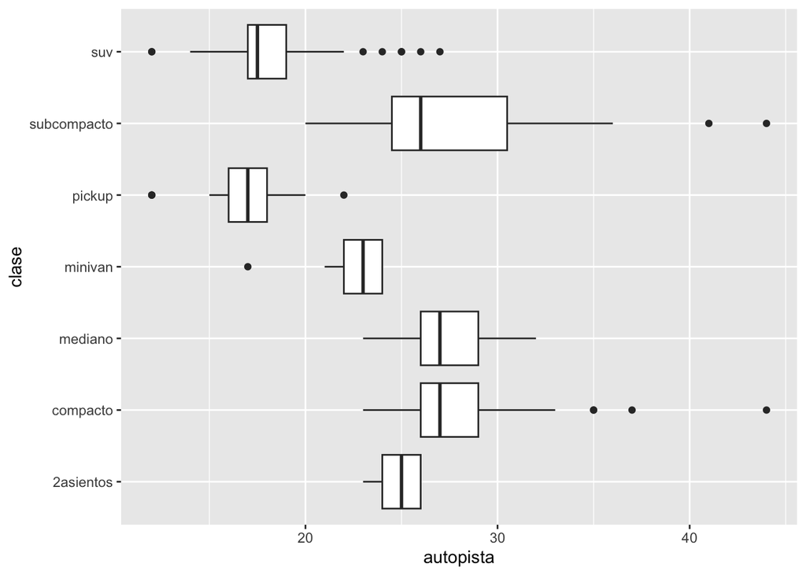

```r
ggplot(data = millas, mapping = aes(x = clase, y = autopista)) +
  geom_boxplot() +
  coord_flip()
```

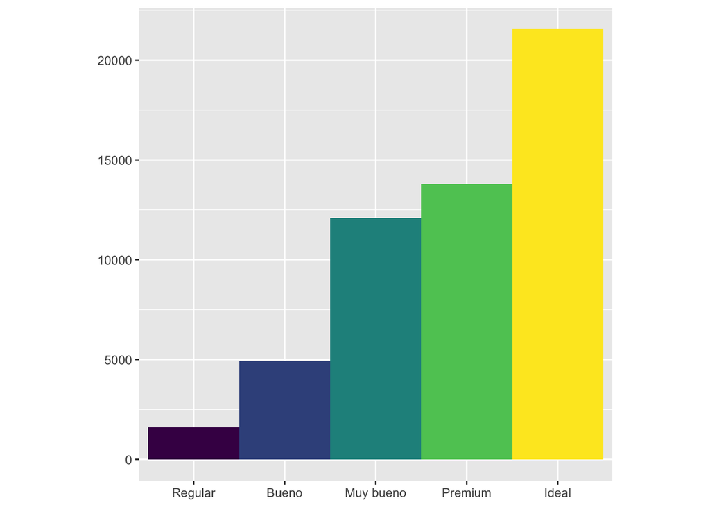

```r
bar <- ggplot(data = diamantes) +
  geom_bar(
    mapping = aes(x = corte, fill = corte),
    show.legend = FALSE,
    width = 1
  ) +
  theme(aspect.ratio = 1) +
  labs(x = NULL, y = NULL)
bar
```

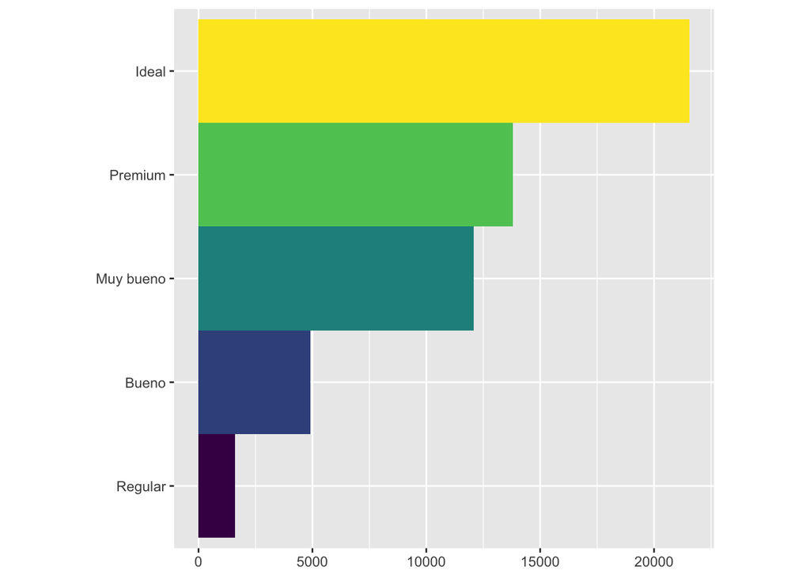

```r
bar + coord_flip()
```

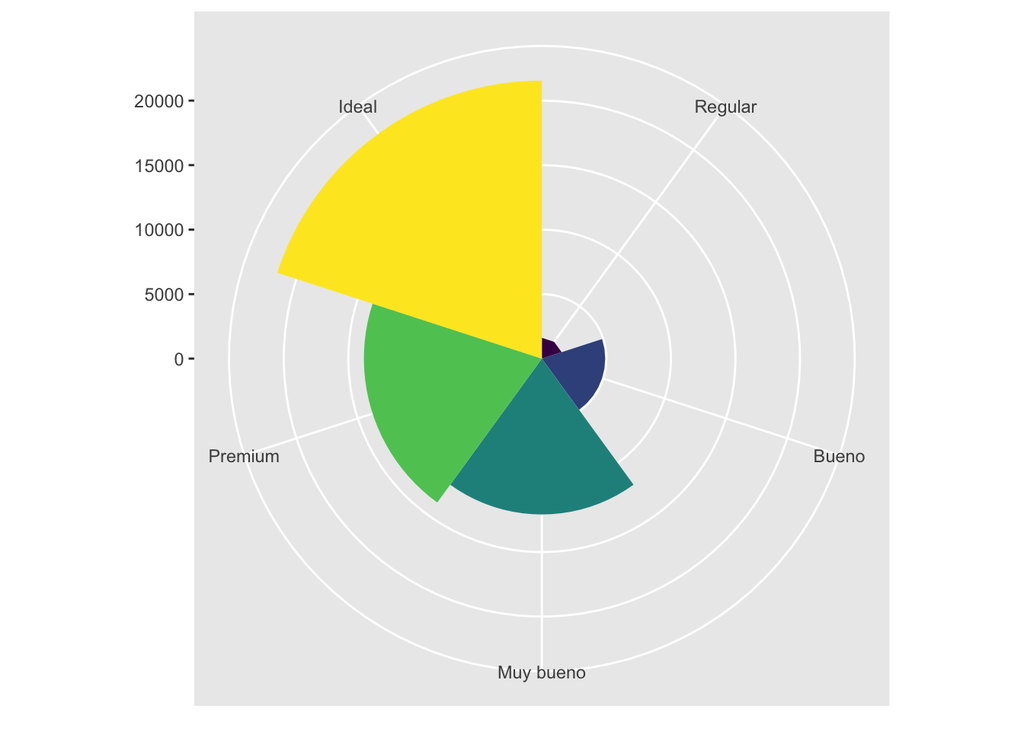

```r
bar + coord_polar()
```

```r
library(readr)
Vuelos_SJU_2018_Ene <- read_csv("Datos/Vuelos_SJU_2018_Ene.csv")
head(Vuelos_SJU_2018_Ene)
```

```
## # A tibble: 6 × 14
##   FL_DATE OP_UNIQUE_CARRIER ORIGIN ORIGIN_CITY_NAME ORIGIN_STATE_ABR DEST
##   <chr>   <chr>             <chr>  <chr>            <chr>            <chr>
## 1 2/1/18  NK                SJU    San Juan, PR     PR               MCO
## 2 2/1/18  AA                MIA    Miami, FL        FL               SJU
## 3 2/1/18  AA                SJU    San Juan, PR     PR               DFW
## 4 2/1/18  AA                SJU    San Juan, PR     PR               MIA
## 5 2/1/18  AA                SJU    San Juan, PR     PR               ORD
## 6 2/1/18  AA                MIA    Miami, FL        FL               SJU
## # ℹ 8 more variables: DEST_CITY_NAME <chr>, DEST_STATE_ABR <chr>,
## #   DEP_TIME <dbl>, DEP_DELAY <dbl>, CRS_ARR_TIME <dbl>, ARR_TIME <dbl>,
## #   ARR_DELAY <dbl>, CANCELLED <dbl>
```

# Visualización de datos

Fecha de la ultima revisión

```
## [1] "2023-08-09"
```

El tema proviene de los siguientes sitios.

English: https://r4ds.had.co.nz/data-visualisation.html

Español: https://r4ds-en-espaniol.netlify.app/visualización-de-datos.html

## Temas:

- Introducción
- paquete “tidyverse”
- datos de “mgp”
- ggplot2
- El concepto de la gramática de gráficos
1. **Ejercicios**:

Hacer los ejercicios en la sección 3.2.4 del libro en español

- Aestética
2. **Ejercicios**:

Hacer los ejercicios en la sección 3.3.1 del libro en español

- Problemas comunes
- Separar en facetas
3. **Ejercicios**:

Hacer los ejercicios en la sección 3.5.1 del libro en español

- Objetos geométricos ***
4. **Ejercicios**:

Hacer los ejercicios en la sección 3.6.1 del libro en español

- Transformación estadísticas
5. **Ejercicios**:

Hacer los ejercicios en la sección 3.7.1 del libro en español

- Ajuste de posición
6. **Ejercicios**:

Hacer los ejercicios en la sección 3.8.1 del libro en español

- Sistema de coordenadas
7. **Ejercicios**:

Hacer los ejercicios en la sección 3.9.1 del libro en español

Ejercicio para entregar ( 6 puntos)

1. Activa el paquete “ggversa”
2. Activa el paquete “tidyverse”
3. Utiliza los datos “PartosInfantes”. Leen la información sobre el archivo Son tres graficas que tendrán que someter
4. Hacer un gráfico de puntos entre el número de muertes de infante y la cantidad de madres que mueren en el parto. (1 punto)
5. Añadir al gráfico anterior un modelo lineal (linear model). Y Demostrando todos los datos con un color por region geografica, o sea añadir un color a los puntos por Grupo “region geográfica”. AM=America, EU= Union Europea, AF= Africa, O=Oceania, AS=Asia, Medio Oriente, (2 puntos)
6. Enseña el modelo de regresion lineal solamente para AFRICA y ASIA (en la misma gráfica) (3 puntos)

Someter las tres gráficas en formato .jpeg o .png en el portal.

```r
library(ggplot2)
library(tidyverse)
library(ggversa)
?PartosInfantes
```

```r
head(PartosInfantes)
```

```
##     NMI  NMP      GSPC Grupo      Pais
## 1  8723  400  605.1878    AM Argentina
## 2    60    5 1720.1595    AM   Bahamas
## 3    42    1 1146.0417    AM  Barbados
## 4   121    2  278.5792    AM    Belize
## 5  7756  540  208.7842    AM   Bolivia
## 6 45682 1400  947.4277    AM    Brazil
```

```r
#unique(PartosInfantes$Pais)
```

Hacer un grafico de puntos entre el numero de muertes por infante y la cantidad la cantidad de madres que mueren en el parto

Añadir al grafico anterior un modelo lineal (linear model)

Añadir un color a los puntos por grupo “region”. AM=America, EU= Union Europea, AF= Africa, O=Oceania, AS=Asia, Medio Oriente,

Demostrando todos los datos con un color por region geografica, enseña el modelo de regresion lineal solamente para AFRICA

# Calculadora sofisticada

Fecha de la ultima revisión

```
## [1] "2023-08-09"
```

```
## [1] "/Users/raymondtremblay/Dropbox/GitHub_Dropbox_Drive/GitHub/Ciencia_Datos_R"
```

El tema proviene de los siguientes sitios.

English: https://r4ds.had.co.nz/workflow-basics.html

Español: https://r4ds-en-espaniol.netlify.app/flujo-de-trabajo-conocimientos-básicos.html

## Temas:

- Conocimiento básicos de programación
- La importancia de los nombres
- Usando funciones

```r
2+2
```

```
## [1] 4
```

```r
(23+3+3)^2+2
```

```
## [1] 843
```

```r
sin(pi/3)
```

```
## [1] 0.8660254
```

```r
log(100)
```

```
## [1] 4.60517
```

```r
log2(100)
```

```
## [1] 6.643856
```

```r
x<- 4
x
```

```
## [1] 4
```

```r
y=3
y
```

```
## [1] 3
```

```r
x/y
```

```
## [1] 1.333333
```

```r
edad_nd=base::seq(101, 110)
edad_nd
```

```
##  [1] 101 102 103 104 105 106 107 108 109 110
```

```r
edad_uprh=c(11:20)
edad_uprh
```

```
##  [1] 11 12 13 14 15 16 17 18 19 20
```

```r
edad=data.frame(edad_nd, edad_uprh)
edad
```

```
##    edad_nd edad_uprh
## 1      101        11
## 2      102        12
## 3      103        13
## 4      104        14
## 5      105        15
## 6      106        16
## 7      107        17
## 8      108        18
## 9      109        19
## 10     110        20
```

```r
library(tidyverse)
library(datos)

ggplot(data=millas) +
  geom_point(mapping = aes(x = cilindrada, y = autopista))
```

[output not shown]

```r
#filter(millas, cilindros = 8)
#filter(diamante, quilate > 3)



length(edad_uprh)
```

```
## [1] 10
```

1. **Ejercicios**:

Hacer los ejercicios en la sección 4.4 del libro en español

Cual son los errores

# Transformacion

Fecha de la ultima revisión

```
## [1] "2023-08-09"
```

El tema proviene de los siguientes sitios.

English: https://r4ds.had.co.nz/transform.html

Español: https://r4ds-en-espaniol.netlify.app/transform.html

```r
library(tidyverse)
library(datos)
head(vuelos)
```

```
## # A tibble: 6 × 19
##    anio   mes   dia horario_salida salida_programada atraso_salida
##   <int> <int> <int>          <int>             <int>         <dbl>
## 1  2013     1     1            517               515             2
## 2  2013     1     1            533               529             4
## 3  2013     1     1            542               540             2
## 4  2013     1     1            544               545            -1
## 5  2013     1     1            554               600            -6
## 6  2013     1     1            554               558            -4
## # ℹ 13 more variables: horario_llegada <int>, llegada_programada <int>,
## #   atraso_llegada <dbl>, aerolinea <chr>, vuelo <int>, codigo_cola <chr>,
## #   origen <chr>, destino <chr>, tiempo_vuelo <dbl>, distancia <dbl>,
## #   hora <dbl>, minuto <dbl>, fecha_hora <dttm>
```

```r
unique(vuelos$destino)
```

```
##   [1] "IAH" "MIA" "BQN" "ATL" "ORD" "FLL" "IAD" "MCO" "PBI" "TPA" "LAX" "SFO"
##  [13] "DFW" "BOS" "LAS" "MSP" "DTW" "RSW" "SJU" "PHX" "BWI" "CLT" "BUF" "DEN"
##  [25] "SNA" "MSY" "SLC" "XNA" "MKE" "SEA" "ROC" "SYR" "SRQ" "RDU" "CMH" "JAX"
##  [37] "CHS" "MEM" "PIT" "SAN" "DCA" "CLE" "STL" "MYR" "JAC" "MDW" "HNL" "BNA"
##  [49] "AUS" "BTV" "PHL" "STT" "EGE" "AVL" "PWM" "IND" "SAV" "CAK" "HOU" "LGB"
##  [61] "DAY" "ALB" "BDL" "MHT" "MSN" "GSO" "CVG" "BUR" "RIC" "GSP" "GRR" "MCI"
##  [73] "ORF" "SAT" "SDF" "PDX" "SJC" "OMA" "CRW" "OAK" "SMF" "TUL" "TYS" "OKC"
##  [85] "PVD" "DSM" "PSE" "BHM" "CAE" "HDN" "BZN" "MTJ" "EYW" "PSP" "ACK" "BGR"
##  [97] "ABQ" "ILM" "MVY" "SBN" "LEX" "CHO" "TVC" "ANC" "LGA"
```

```r
vuelos %>%
  filter(destino=="SJU") %>%
  filter(mes==12, dia==25) # pipe Command shift M
```

```
## # A tibble: 21 × 19
##     anio   mes   dia horario_salida salida_programada atraso_salida
##    <int> <int> <int>          <int>             <int>         <dbl>
##  1  2013    12    25            604               611            -7
##  2  2013    12    25            654               656            -2
##  3  2013    12    25            712               705             7
##  4  2013    12    25            730               730             0
##  5  2013    12    25            736               739            -3
##  6  2013    12    25            759               805            -6
##  7  2013    12    25            947               947             0
##  8  2013    12    25           1202              1206            -4
##  9  2013    12    25           1254               900           234
## 10  2013    12    25           1354              1330            24
## # ℹ 11 more rows
## # ℹ 13 more variables: horario_llegada <int>, llegada_programada <int>,
## #   atraso_llegada <dbl>, aerolinea <chr>, vuelo <int>, codigo_cola <chr>,
## #   origen <chr>, destino <chr>, tiempo_vuelo <dbl>, distancia <dbl>,
## #   hora <dbl>, minuto <dbl>, fecha_hora <dttm>
```

```r
library(tidyverse)
vuelos %>%
  filter(destino=="SJU")
```

```
## # A tibble: 5,819 × 19
##     anio   mes   dia horario_salida salida_programada atraso_salida
##    <int> <int> <int>          <int>             <int>         <dbl>
##  1  2013     1     1            615               615             0
##  2  2013     1     1            628               630            -2
##  3  2013     1     1            701               700             1
##  4  2013     1     1            711               715            -4
##  5  2013     1     1            820               820             0
##  6  2013     1     1            820               820             0
##  7  2013     1     1            840               845            -5
##  8  2013     1     1            926               929            -3
##  9  2013     1     1           1202              1159             3
## 10  2013     1     1           1245              1249            -4
## # ℹ 5,809 more rows
## # ℹ 13 more variables: horario_llegada <int>, llegada_programada <int>,
## #   atraso_llegada <dbl>, aerolinea <chr>, vuelo <int>, codigo_cola <chr>,
## #   origen <chr>, destino <chr>, tiempo_vuelo <dbl>, distancia <dbl>,
## #   hora <dbl>, minuto <dbl>, fecha_hora <dttm>
```

```r
df_dia_cumpl=vuelos %>%
filter(destino =="SJU") %>%
  filter(mes== 8, dia== 1)

df_dia_cumpl
```

```
## # A tibble: 19 × 19
##     anio   mes   dia horario_salida salida_programada atraso_salida
##    <int> <int> <int>          <int>             <int>         <dbl>
##  1  2013     8     1             32              2359            33
##  2  2013     8     1             33              2231           122
##  3  2013     8     1            609               611            -2
##  4  2013     8     1            638               640            -2
##  5  2013     8     1            655               655             0
##  6  2013     8     1            704               705            -1
##  7  2013     8     1            845               850            -5
##  8  2013     8     1            854               900            -6
##  9  2013     8     1            910               915            -5
## 10  2013     8     1            918               730           108
## 11  2013     8     1           1101              1055             6
## 12  2013     8     1           1306              1255            11
## 13  2013     8     1           1457              1455             2
## 14  2013     8     1           1508              1429            39
## 15  2013     8     1           1551              1545             6
## 16  2013     8     1           1732              1706            26
## 17  2013     8     1           2036              2007            29
## 18  2013     8     1           2141              2101            40
## 19  2013     8     1           2257              2115           102
## # ℹ 13 more variables: horario_llegada <int>, llegada_programada <int>,
## #   atraso_llegada <dbl>, aerolinea <chr>, vuelo <int>, codigo_cola <chr>,
## #   origen <chr>, destino <chr>, tiempo_vuelo <dbl>, distancia <dbl>,
## #   hora <dbl>, minuto <dbl>, fecha_hora <dttm>
```

```r
names(vuelos)
```

```
##  [1] "anio"               "mes"                "dia"
##  [4] "horario_salida"     "salida_programada"  "atraso_salida"
##  [7] "horario_llegada"    "llegada_programada" "atraso_llegada"
## [10] "aerolinea"          "vuelo"              "codigo_cola"
## [13] "origen"             "destino"            "tiempo_vuelo"
## [16] "distancia"          "hora"               "minuto"
## [19] "fecha_hora"
```

```r
vuelos %>%
  select(mes, dia, atraso_salida, atraso_llegada) %>%
  filter(mes==11) %>%
  arrange(desc(atraso_salida))
```

```
## # A tibble: 27,268 × 4
##      mes   dia atraso_salida atraso_llegada
##    <int> <int>         <dbl>          <dbl>
##  1    11     3           798            796
##  2    11    24           636            614
##  3    11     4           413            434
##  4    11    27           408            396
##  5    11    20           398            389
##  6    11    11           367            344
##  7    11    21           351            346
##  8    11    24           347            304
##  9    11    24           341            290
## 10    11    22           339            329
## # ℹ 27,258 more rows
```

## Temas: Reconocer y aplicar las diferentes funciones

- Tipos de variables:
  - int
  - dbl
  - chr
  - dttm
  - lgl
  - fctr
  - date
- Funciones de dplyr:
  - filter()
  - arrange()
  - select()
  - summarize()
  - group_by()

```r
library(datos)
library(tidyverse)
por_dia <- group_by(vuelos, dia)%>%
summarise(atraso_promedio = mean(atraso_salida, na.rm = TRUE))
por_dia
```

```
## # A tibble: 31 × 2
##      dia atraso_promedio
##    <int>           <dbl>
##  1     1           14.2
##  2     2           14.1
##  3     3           10.8
##  4     4            5.79
##  5     5            7.82
##  6     6            6.99
##  7     7           14.3
##  8     8           21.8
##  9     9           14.6
## 10    10           18.3
## # ℹ 21 more rows
```

```r
vuelos %>%
  select(anio, mes, dia, atraso_salida) %>%
  group_by(mes) %>%
  summarise(atraso = mean(atraso_salida, na.rm = TRUE))
```

```
## # A tibble: 12 × 2
##      mes atraso
##    <int>  <dbl>
##  1     1  10.0
##  2     2  10.8
##  3     3  13.2
##  4     4  13.9
##  5     5  13.0
##  6     6  20.8
##  7     7  21.7
##  8     8  12.6
##  9     9   6.72
## 10    10   6.24
## 11    11   5.44
## 12    12  16.6
```

- Operaciones lógicas boolean:
  - & “ampersand”
  - “|” or= “o”
  - !, no incluye, excluir….
  - %in%, filtrar para multiples valores
  - ==, es igual a… “exactamente”
  - “<”
  - “>”

Bollean, que incluye multimple opciones %in%

```r
vuelos %>%
  select(anio, mes, dia, atraso_salida) %>%
  group_by(mes) %>%
  filter(mes %in% c(1:6)) %>%
  summarise(atraso = mean(atraso_salida, na.rm = TRUE))
```

```
## # A tibble: 6 × 2
##     mes atraso
##   <int>  <dbl>
## 1     1   10.0
## 2     2   10.8
## 3     3   13.2
## 4     4   13.9
## 5     5   13.0
## 6     6   20.8
```

Otra alternativa

```r
vuelos %>%
  select(anio, mes, dia, atraso_salida) %>%
  filter(mes == 11 | mes == 12)
```

```
## # A tibble: 55,403 × 4
##     anio   mes   dia atraso_salida
##    <int> <int> <int>         <dbl>
##  1  2013    11     1             6
##  2  2013    11     1           105
##  3  2013    11     1            -5
##  4  2013    11     1            -6
##  5  2013    11     1            -3
##  6  2013    11     1           -11
##  7  2013    11     1           -10
##  8  2013    11     1            -6
##  9  2013    11     1            -6
## 10  2013    11     1            -6
## # ℹ 55,393 more rows
```

```r
#%>%
 # summarise(atraso = mean(atraso_salida, na.rm = TRUE))
```

& el “y”

```r
names(vuelos)
```

```
##  [1] "anio"               "mes"                "dia"
##  [4] "horario_salida"     "salida_programada"  "atraso_salida"
##  [7] "horario_llegada"    "llegada_programada" "atraso_llegada"
## [10] "aerolinea"          "vuelo"              "codigo_cola"
## [13] "origen"             "destino"            "tiempo_vuelo"
## [16] "distancia"          "hora"               "minuto"
## [19] "fecha_hora"
```

```r
vuelos %>%
  select(anio, mes, dia, atraso_salida, aerolinea) %>%
  filter(mes == 12 & dia == 25 & aerolinea=="AA")
```

```
## # A tibble: 78 × 5
##     anio   mes   dia atraso_salida aerolinea
##    <int> <int> <int>         <dbl> <chr>
##  1  2013    12    25             2 AA
##  2  2013    12    25            -4 AA
##  3  2013    12    25             1 AA
##  4  2013    12    25             0 AA
##  5  2013    12    25            -3 AA
##  6  2013    12    25            -2 AA
##  7  2013    12    25            26 AA
##  8  2013    12    25            -7 AA
##  9  2013    12    25            -6 AA
## 10  2013    12    25            21 AA
## # ℹ 68 more rows
```

!, el “no”, excluye

```r
vuelos %>%
  select(anio, mes, dia, atraso_salida) %>%
  filter(mes == 11 & !dia %in% c(1:10)) %>%
  group_by(dia) %>%
  summarise(atraso = mean(atraso_salida, na.rm = TRUE))
```

```
## # A tibble: 20 × 2
##      dia atraso
##    <int>  <dbl>
##  1    11  3.34
##  2    12  8.55
##  3    13  2.60
##  4    14  2.16
##  5    15  0.587
##  6    16  1.70
##  7    17 21.9
##  8    18  5.59
##  9    19  0.439
## 10    20  1.78
## 11    21  3.11
## 12    22 11.0
## 13    23  3.49
## 14    24 14.7
## 15    25  3.32
## 16    26  7.97
## 17    27 16.7
## 18    28  6.06
## 19    29  0.145
## 20    30  2.79
```

1. **Ejercicios**:

Hacer los ejercicios en la sección 5.2.4 del libro en español

5.2.4 Ejercicios - Encuentra todos los vuelos que:

- Tuvieron un retraso de llegada de dos o más horas

```r
#names(vuelos)

vuelos %>%
  filter(atraso_llegada >=120)
```

```
## # A tibble: 10,200 × 19
##     anio   mes   dia horario_salida salida_programada atraso_salida
##    <int> <int> <int>          <int>             <int>         <dbl>
##  1  2013     1     1            811               630           101
##  2  2013     1     1            848              1835           853
##  3  2013     1     1            957               733           144
##  4  2013     1     1           1114               900           134
##  5  2013     1     1           1505              1310           115
##  6  2013     1     1           1525              1340           105
##  7  2013     1     1           1549              1445            64
##  8  2013     1     1           1558              1359           119
##  9  2013     1     1           1732              1630            62
## 10  2013     1     1           1803              1620           103
## # ℹ 10,190 more rows
## # ℹ 13 more variables: horario_llegada <int>, llegada_programada <int>,
## #   atraso_llegada <dbl>, aerolinea <chr>, vuelo <int>, codigo_cola <chr>,
## #   origen <chr>, destino <chr>, tiempo_vuelo <dbl>, distancia <dbl>,
## #   hora <dbl>, minuto <dbl>, fecha_hora <dttm>
```

- Volaron a Houston (IAH o HOU)

Cual son estos aeropuertos, Hou == Houston, IAH == George Bush, Texas

```r
vuelos %>%
  filter(destino %in% c("IAH", "HOU"))
```

```
## # A tibble: 9,313 × 19
##     anio   mes   dia horario_salida salida_programada atraso_salida
##    <int> <int> <int>          <int>             <int>         <dbl>
##  1  2013     1     1            517               515             2
##  2  2013     1     1            533               529             4
##  3  2013     1     1            623               627            -4
##  4  2013     1     1            728               732            -4
##  5  2013     1     1            739               739             0
##  6  2013     1     1            908               908             0
##  7  2013     1     1           1028              1026             2
##  8  2013     1     1           1044              1045            -1
##  9  2013     1     1           1114               900           134
## 10  2013     1     1           1205              1200             5
## # ℹ 9,303 more rows
## # ℹ 13 more variables: horario_llegada <int>, llegada_programada <int>,
## #   atraso_llegada <dbl>, aerolinea <chr>, vuelo <int>, codigo_cola <chr>,
## #   origen <chr>, destino <chr>, tiempo_vuelo <dbl>, distancia <dbl>,
## #   hora <dbl>, minuto <dbl>, fecha_hora <dttm>
```

```r
vuelos %>%
select(anio, mes, dia, destino, aerolinea, atraso_llegada) %>%
filter(destino %in% c("IAH", "HOU"))
```

```
## # A tibble: 9,313 × 6
##     anio   mes   dia destino aerolinea atraso_llegada
##    <int> <int> <int> <chr>   <chr>              <dbl>
##  1  2013     1     1 IAH     UA                    11
##  2  2013     1     1 IAH     UA                    20
##  3  2013     1     1 IAH     UA                     1
##  4  2013     1     1 IAH     UA                     3
##  5  2013     1     1 IAH     UA                    26
##  6  2013     1     1 IAH     UA                     9
##  7  2013     1     1 IAH     UA                    11
##  8  2013     1     1 IAH     UA                     1
##  9  2013     1     1 IAH     UA                   145
## 10  2013     1     1 IAH     UA                    -2
## # ℹ 9,303 more rows
```

- Fueron operados por United, American o Delta

```r
unique(vuelos$aerolinea)
```

```
##  [1] "UA" "AA" "B6" "DL" "EV" "MQ" "US" "WN" "VX" "FL" "AS" "9E" "F9" "HA" "YV"
## [16] "OO"
```

```r
vuelos %>%
  filter(aerolinea %in% c("UA", "AA","DL"))
```

```
## # A tibble: 139,504 × 19
##     anio   mes   dia horario_salida salida_programada atraso_salida
##    <int> <int> <int>          <int>             <int>         <dbl>
##  1  2013     1     1            517               515             2
##  2  2013     1     1            533               529             4
##  3  2013     1     1            542               540             2
##  4  2013     1     1            554               600            -6
##  5  2013     1     1            554               558            -4
##  6  2013     1     1            558               600            -2
##  7  2013     1     1            558               600            -2
##  8  2013     1     1            558               600            -2
##  9  2013     1     1            559               600            -1
## 10  2013     1     1            559               600            -1
## # ℹ 139,494 more rows
## # ℹ 13 more variables: horario_llegada <int>, llegada_programada <int>,
## #   atraso_llegada <dbl>, aerolinea <chr>, vuelo <int>, codigo_cola <chr>,
## #   origen <chr>, destino <chr>, tiempo_vuelo <dbl>, distancia <dbl>,
## #   hora <dbl>, minuto <dbl>, fecha_hora <dttm>
```

- Partieron en invierno del hemisferio sur (julio, agosto y septiembre)

```r
vuelos %>%
  filter(mes %in% c(6:8))
```

```
## # A tibble: 86,995 × 19
##     anio   mes   dia horario_salida salida_programada atraso_salida
##    <int> <int> <int>          <int>             <int>         <dbl>
##  1  2013     6     1              2              2359             3
##  2  2013     6     1            451               500            -9
##  3  2013     6     1            506               515            -9
##  4  2013     6     1            534               545           -11
##  5  2013     6     1            538               545            -7
##  6  2013     6     1            539               540            -1
##  7  2013     6     1            546               600           -14
##  8  2013     6     1            551               600            -9
##  9  2013     6     1            552               600            -8
## 10  2013     6     1            553               600            -7
## # ℹ 86,985 more rows
## # ℹ 13 more variables: horario_llegada <int>, llegada_programada <int>,
## #   atraso_llegada <dbl>, aerolinea <chr>, vuelo <int>, codigo_cola <chr>,
## #   origen <chr>, destino <chr>, tiempo_vuelo <dbl>, distancia <dbl>,
## #   hora <dbl>, minuto <dbl>, fecha_hora <dttm>
```

```r
vuelos %>%
filter(mes %in% c(7, 8, 9))
```

```
## # A tibble: 86,326 × 19
##     anio   mes   dia horario_salida salida_programada atraso_salida
##    <int> <int> <int>          <int>             <int>         <dbl>
##  1  2013     7     1              1              2029           212
##  2  2013     7     1              2              2359             3
##  3  2013     7     1             29              2245           104
##  4  2013     7     1             43              2130           193
##  5  2013     7     1             44              2150           174
##  6  2013     7     1             46              2051           235
##  7  2013     7     1             48              2001           287
##  8  2013     7     1             58              2155           183
##  9  2013     7     1            100              2146           194
## 10  2013     7     1            100              2245           135
## # ℹ 86,316 more rows
## # ℹ 13 more variables: horario_llegada <int>, llegada_programada <int>,
## #   atraso_llegada <dbl>, aerolinea <chr>, vuelo <int>, codigo_cola <chr>,
## #   origen <chr>, destino <chr>, tiempo_vuelo <dbl>, distancia <dbl>,
## #   hora <dbl>, minuto <dbl>, fecha_hora <dttm>
```

- Llegaron más de dos horas tarde, pero no salieron tarde

```r
names(vuelos)
```

```
##  [1] "anio"               "mes"                "dia"
##  [4] "horario_salida"     "salida_programada"  "atraso_salida"
##  [7] "horario_llegada"    "llegada_programada" "atraso_llegada"
## [10] "aerolinea"          "vuelo"              "codigo_cola"
## [13] "origen"             "destino"            "tiempo_vuelo"
## [16] "distancia"          "hora"               "minuto"
## [19] "fecha_hora"
```

```r
vuelos %>%
  filter(atraso_llegada>120 |atraso_salida <0)
```

```
## # A tibble: 193,583 × 19
##     anio   mes   dia horario_salida salida_programada atraso_salida
##    <int> <int> <int>          <int>             <int>         <dbl>
##  1  2013     1     1            544               545            -1
##  2  2013     1     1            554               600            -6
##  3  2013     1     1            554               558            -4
##  4  2013     1     1            555               600            -5
##  5  2013     1     1            557               600            -3
##  6  2013     1     1            557               600            -3
##  7  2013     1     1            558               600            -2
##  8  2013     1     1            558               600            -2
##  9  2013     1     1            558               600            -2
## 10  2013     1     1            558               600            -2
## # ℹ 193,573 more rows
## # ℹ 13 more variables: horario_llegada <int>, llegada_programada <int>,
## #   atraso_llegada <dbl>, aerolinea <chr>, vuelo <int>, codigo_cola <chr>,
## #   origen <chr>, destino <chr>, tiempo_vuelo <dbl>, distancia <dbl>,
## #   hora <dbl>, minuto <dbl>, fecha_hora <dttm>
```

```r
vuelos %>%
select(atraso_llegada, atraso_salida) %>%
filter(atraso_llegada >= 120 & atraso_salida <= 0)
```

```
## # A tibble: 29 × 2
##    atraso_llegada atraso_salida
##             <dbl>         <dbl>
##  1            124            -1
##  2            130             0
##  3            124            -2
##  4            122            -3
##  5            194            -2
##  6            140            -3
##  7            124            -5
##  8            179            -2
##  9            143            -5
## 10            127            -3
## # ℹ 19 more rows
```

- Se retrasaron por lo menos una hora, pero repusieron más de 30 minutos en vuelo

```r
vuelos
```

```
## # A tibble: 336,776 × 19
##     anio   mes   dia horario_salida salida_programada atraso_salida
##    <int> <int> <int>          <int>             <int>         <dbl>
##  1  2013     1     1            517               515             2
##  2  2013     1     1            533               529             4
##  3  2013     1     1            542               540             2
##  4  2013     1     1            544               545            -1
##  5  2013     1     1            554               600            -6
##  6  2013     1     1            554               558            -4
##  7  2013     1     1            555               600            -5
##  8  2013     1     1            557               600            -3
##  9  2013     1     1            557               600            -3
## 10  2013     1     1            558               600            -2
## # ℹ 336,766 more rows
## # ℹ 13 more variables: horario_llegada <int>, llegada_programada <int>,
## #   atraso_llegada <dbl>, aerolinea <chr>, vuelo <int>, codigo_cola <chr>,
## #   origen <chr>, destino <chr>, tiempo_vuelo <dbl>, distancia <dbl>,
## #   hora <dbl>, minuto <dbl>, fecha_hora <dttm>
```

```r
?vuelos
#select(atraso_salida, atraso_llegada ) %>%
#filter(atraso_salida >= 60 & atraso_llegada <= 30)
```

- Partieron entre la medianoche y las 6a.m. (incluyente)

# 360 minutos

```r
names(vuelos)
```

```
##  [1] "anio"               "mes"                "dia"
##  [4] "horario_salida"     "salida_programada"  "atraso_salida"
##  [7] "horario_llegada"    "llegada_programada" "atraso_llegada"
## [10] "aerolinea"          "vuelo"              "codigo_cola"
## [13] "origen"             "destino"            "tiempo_vuelo"
## [16] "distancia"          "hora"               "minuto"
## [19] "fecha_hora"
```

```r
vuelos %>%
select(horario_salida) %>%
filter(horario_salida <=600)
```

```
## # A tibble: 9,344 × 1
##    horario_salida
##             <int>
##  1            517
##  2            533
##  3            542
##  4            544
##  5            554
##  6            554
##  7            555
##  8            557
##  9            557
## 10            558
## # ℹ 9,334 more rows
```

- Otra función de dplyr que es útil para usar filtros es between(). ¿Qué hace? ¿Puedes usarla para simplificar el código necesario para responder a los desafíos anteriores?

```r
vuelos %>%
select(horario_salida) %>%
filter(between(horario_salida,00, 360))
```

```
## # A tibble: 1,179 × 1
##    horario_salida
##             <int>
##  1             42
##  2            126
##  3             32
##  4             50
##  5            235
##  6             25
##  7            106
##  8             14
##  9             37
## 10             16
## # ℹ 1,169 more rows
```

```r
vuelos %>%
select(horario_salida) %>%
filter(between(horario_salida, 00, 360))
```

```
## # A tibble: 1,179 × 1
##    horario_salida
##             <int>
##  1             42
##  2            126
##  3             32
##  4             50
##  5            235
##  6             25
##  7            106
##  8             14
##  9             37
## 10             16
## # ℹ 1,169 more rows
```

- ¿Cuántos vuelos tienen datos faltantes en horario_salida?
- ¿Qué otras variables tienen valores faltantes?
- ¿Qué representan estas filas?

```r
vuelos %>%
select(horario_salida) %>%
is.na() %>%
  table()
```

```
## .
##  FALSE   TRUE
## 328521   8255
```

```r
#vuelos %>%
#select(horario_salida) %>%
#  table()
```

```r
library(tidyverse)
2^2
```

```
## [1] 4
```

```r
1^2
```

```
## [1] 1
```

```r
1^0
```

```
## [1] 1
```

```r
NA^0
```

```
## [1] 1
```

```r
#NA==1
NA|TRUE
```

```
## [1] TRUE
```

```r
FALSE & NA
```

```
## [1] FALSE
```

```r
NA * 0
```

```
## [1] NA
```

```r
NA * 1
```

```
## [1] NA
```

```r
12 * 3
```

```
## [1] 36
```

```r
NA - 3
```

```
## [1] NA
```

Use data from a link on the web

*** filter for Puerto Rico only

COVID_PR

```r
library(data.table)
#url_COVID_PR=fread("https://raw.githubusercontent.com/rafalab/pr-covid/master/dashboard/data/DatosMortalidad.csv")

#write_csv(url_COVID_PR, "url_COVID_PR.csv")

library(readr)
url_COVID_PR <- read_csv("Datos/url_COVID_PR.csv")
url_COVID=url_COVID_PR

names(url_COVID)
```

```
##  [1] "...1"               "Fecha"              "Muertes"
##  [4] "IncrementoMuertes"  "CasosPCR_Salud"     "IncCasosPCR_Salud"
##  [7] "CasosSaludNuevo"    "IncCasosSaludNuevo" "HospitCOV19"
## [10] "CamasICU"           "CamasICU_disp"      "Ventiladores"
## [13] "MuertesSalud"       "IncMueSalud"        "VacDoses"
## [16] "VacAdm"             "N1MoreDoses"        "N2Doses"
```

```r
head(url_COVID)
```

```
## # A tibble: 6 × 18
##    ...1 Fecha   Muertes IncrementoMuertes CasosPCR_Salud IncCasosPCR_Salud
##   <dbl> <chr>     <dbl>             <dbl>          <dbl>             <dbl>
## 1     1 3/12/20       0                 0             NA                NA
## 2     2 3/13/20       0                 0             NA                NA
## 3     3 3/14/20       0                 0             NA                NA
## 4     4 3/15/20       0                 0             NA                NA
## 5     5 3/16/20       0                 0             NA                NA
## 6     6 3/17/20       0                 0             NA                NA
## # ℹ 12 more variables: CasosSaludNuevo <dbl>, IncCasosSaludNuevo <dbl>,
## #   HospitCOV19 <dbl>, CamasICU <dbl>, CamasICU_disp <dbl>, Ventiladores <dbl>,
## #   MuertesSalud <dbl>, IncMueSalud <dbl>, VacDoses <dbl>, VacAdm <dbl>,
## #   N1MoreDoses <dbl>, N2Doses <dbl>
```

```r
tail(url_COVID)
```

```
## # A tibble: 6 × 18
##    ...1 Fecha    Muertes IncrementoMuertes CasosPCR_Salud IncCasosPCR_Salud
##   <dbl> <chr>      <dbl>             <dbl>          <dbl>             <dbl>
## 1   582 10/14/21    3205                 4         150812               181
## 2   583 10/15/21    3207                 2         150892                80
## 3   584 10/16/21    3207                 0         150969                77
## 4   585 10/17/21    3207                 0         151027                58
## 5   586 10/18/21    3209                 2         151033                 6
## 6   587 10/19/21    3213                 4         151089                56
## # ℹ 12 more variables: CasosSaludNuevo <dbl>, IncCasosSaludNuevo <dbl>,
## #   HospitCOV19 <dbl>, CamasICU <dbl>, CamasICU_disp <dbl>, Ventiladores <dbl>,
## #   MuertesSalud <dbl>, IncMueSalud <dbl>, VacDoses <dbl>, VacAdm <dbl>,
## #   N1MoreDoses <dbl>, N2Doses <dbl>
```

```r
 url_COVID %>%
  select(IncrementoMuertes) %>%
  summarise(Prom_muerte_dia = mean(IncrementoMuertes, na.rm = TRUE),
            maximo_muerte_dia = max(IncrementoMuertes, na.rm = TRUE))
```

```
## # A tibble: 1 × 2
##   Prom_muerte_dia maximo_muerte_dia
##             <dbl>             <dbl>
## 1            5.47                29
```

arrange()

```r
vuelos %>%
  select(horario_salida) %>%
  arrange()
```

```
## # A tibble: 336,776 × 1
##    horario_salida
##             <int>
##  1            517
##  2            533
##  3            542
##  4            544
##  5            554
##  6            554
##  7            555
##  8            557
##  9            557
## 10            558
## # ℹ 336,766 more rows
```

```r
vuelos %>%
  arrange(desc(horario_salida))
```

```
## # A tibble: 336,776 × 19
##     anio   mes   dia horario_salida salida_programada atraso_salida
##    <int> <int> <int>          <int>             <int>         <dbl>
##  1  2013    10    30           2400              2359             1
##  2  2013    11    27           2400              2359             1
##  3  2013    12     5           2400              2359             1
##  4  2013    12     9           2400              2359             1
##  5  2013    12     9           2400              2250            70
##  6  2013    12    13           2400              2359             1
##  7  2013    12    19           2400              2359             1
##  8  2013    12    29           2400              1700           420
##  9  2013     2     7           2400              2359             1
## 10  2013     2     7           2400              2359             1
## # ℹ 336,766 more rows
## # ℹ 13 more variables: horario_llegada <int>, llegada_programada <int>,
## #   atraso_llegada <dbl>, aerolinea <chr>, vuelo <int>, codigo_cola <chr>,
## #   origen <chr>, destino <chr>, tiempo_vuelo <dbl>, distancia <dbl>,
## #   hora <dbl>, minuto <dbl>, fecha_hora <dttm>
```

5.3.1 Ejercicios

```r
?vuelos
vuelos %>%
  select(atraso_llegada, horario_salida) %>%
  arrange(atraso_llegada, desc(horario_salida))
```

```
## # A tibble: 336,776 × 2
##    atraso_llegada horario_salida
##             <dbl>          <int>
##  1            -86           1715
##  2            -79            719
##  3            -75           1947
##  4            -75           1826
##  5            -74           1816
##  6            -73           1926
##  7            -71           2054
##  8            -71           1753
##  9            -71            657
## 10            -70           1801
## # ℹ 336,766 more rows
```

Encuentra los vuelos que salieron más temprano.

```r
vuelos %>% select(horario_salida) %>% filter(horario_salida >= 600) %>% filter(horario_salida > 2400)
```

```
## # A tibble: 0 × 1
## # ℹ 1 variable: horario_salida <int>
```

```r
names(vuelos)
```

```
##  [1] "anio"               "mes"                "dia"
##  [4] "horario_salida"     "salida_programada"  "atraso_salida"
##  [7] "horario_llegada"    "llegada_programada" "atraso_llegada"
## [10] "aerolinea"          "vuelo"              "codigo_cola"
## [13] "origen"             "destino"            "tiempo_vuelo"
## [16] "distancia"          "hora"               "minuto"
## [19] "fecha_hora"
```

```r
vuelos %>%
  select(atraso_salida) %>%
  arrange(atraso_salida)
```

```
## # A tibble: 336,776 × 1
##    atraso_salida
##            <dbl>
##  1           -43
##  2           -33
##  3           -32
##  4           -30
##  5           -27
##  6           -26
##  7           -25
##  8           -25
##  9           -24
## 10           -24
## # ℹ 336,766 more rows
```

Ordena vuelos para encontrar los vuelos más rápidos (que viajaron a mayor velocidad).

```r
vuelos %>%
  mutate(velocidad=distancia/tiempo_vuelo) %>%
  arrange(desc(velocidad))
```

```
## # A tibble: 336,776 × 20
##     anio   mes   dia horario_salida salida_programada atraso_salida
##    <int> <int> <int>          <int>             <int>         <dbl>
##  1  2013     5    25           1709              1700             9
##  2  2013     7     2           1558              1513            45
##  3  2013     5    13           2040              2025            15
##  4  2013     3    23           1914              1910             4
##  5  2013     1    12           1559              1600            -1
##  6  2013    11    17            650               655            -5
##  7  2013     2    21           2355              2358            -3
##  8  2013    11    17            759               800            -1
##  9  2013    11    16           2003              1925            38
## 10  2013    11    16           2349              2359           -10
## # ℹ 336,766 more rows
## # ℹ 14 more variables: horario_llegada <int>, llegada_programada <int>,
## #   atraso_llegada <dbl>, aerolinea <chr>, vuelo <int>, codigo_cola <chr>,
## #   origen <chr>, destino <chr>, tiempo_vuelo <dbl>, distancia <dbl>,
## #   hora <dbl>, minuto <dbl>, fecha_hora <dttm>, velocidad <dbl>
```

¿Cuáles vuelos viajaron más lejos?

```r
vuelos %>%
  arrange(desc(distancia))
```

```
## # A tibble: 336,776 × 19
##     anio   mes   dia horario_salida salida_programada atraso_salida
##    <int> <int> <int>          <int>             <int>         <dbl>
##  1  2013     1     1            857               900            -3
##  2  2013     1     2            909               900             9
##  3  2013     1     3            914               900            14
##  4  2013     1     4            900               900             0
##  5  2013     1     5            858               900            -2
##  6  2013     1     6           1019               900            79
##  7  2013     1     7           1042               900           102
##  8  2013     1     8            901               900             1
##  9  2013     1     9            641               900          1301
## 10  2013     1    10            859               900            -1
## # ℹ 336,766 more rows
## # ℹ 13 more variables: horario_llegada <int>, llegada_programada <int>,
## #   atraso_llegada <dbl>, aerolinea <chr>, vuelo <int>, codigo_cola <chr>,
## #   origen <chr>, destino <chr>, tiempo_vuelo <dbl>, distancia <dbl>,
## #   hora <dbl>, minuto <dbl>, fecha_hora <dttm>
```

¿Cuál viajó más cerca?

```r
vuelos %>%
  arrange(distancia)
```

```
## # A tibble: 336,776 × 19
##     anio   mes   dia horario_salida salida_programada atraso_salida
##    <int> <int> <int>          <int>             <int>         <dbl>
##  1  2013     7    27             NA               106            NA
##  2  2013     1     3           2127              2129            -2
##  3  2013     1     4           1240              1200            40
##  4  2013     1     4           1829              1615           134
##  5  2013     1     4           2128              2129            -1
##  6  2013     1     5           1155              1200            -5
##  7  2013     1     6           2125              2129            -4
##  8  2013     1     7           2124              2129            -5
##  9  2013     1     8           2127              2130            -3
## 10  2013     1     9           2126              2129            -3
## # ℹ 336,766 more rows
## # ℹ 13 more variables: horario_llegada <int>, llegada_programada <int>,
## #   atraso_llegada <dbl>, aerolinea <chr>, vuelo <int>, codigo_cola <chr>,
## #   origen <chr>, destino <chr>, tiempo_vuelo <dbl>, distancia <dbl>,
## #   hora <dbl>, minuto <dbl>, fecha_hora <dttm>
```

- Otra función
  - desc()
2. **Ejercicios**:

Hacer los ejercicios en la sección 5.3.1 del libro en español

- Otras funciones:
  - starts_with()
  - ends_with()
  - contains()
  - matches(“(.)\1”) # paquete STRING
  - rename()
  - everything()

## starts_with(), ends_with()

```r
names(vuelos)
```

```
##  [1] "anio"               "mes"                "dia"
##  [4] "horario_salida"     "salida_programada"  "atraso_salida"
##  [7] "horario_llegada"    "llegada_programada" "atraso_llegada"
## [10] "aerolinea"          "vuelo"              "codigo_cola"
## [13] "origen"             "destino"            "tiempo_vuelo"
## [16] "distancia"          "hora"               "minuto"
## [19] "fecha_hora"
```

```r
vuelos %>%
  select(horario_salida)
```

```
## # A tibble: 336,776 × 1
##    horario_salida
##             <int>
##  1            517
##  2            533
##  3            542
##  4            544
##  5            554
##  6            554
##  7            555
##  8            557
##  9            557
## 10            558
## # ℹ 336,766 more rows
```

```r
vuelos %>%
  select(starts_with("horario"))
```

```
## # A tibble: 336,776 × 2
##    horario_salida horario_llegada
##             <int>           <int>
##  1            517             830
##  2            533             850
##  3            542             923
##  4            544            1004
##  5            554             812
##  6            554             740
##  7            555             913
##  8            557             709
##  9            557             838
## 10            558             753
## # ℹ 336,766 more rows
```

```r
vuelos %>%
  select(ends_with("salida"))
```

```
## # A tibble: 336,776 × 2
##    horario_salida atraso_salida
##             <int>         <dbl>
##  1            517             2
##  2            533             4
##  3            542             2
##  4            544            -1
##  5            554            -6
##  6            554            -4
##  7            555            -5
##  8            557            -3
##  9            557            -3
## 10            558            -2
## # ℹ 336,766 more rows
```

```r
vuelos %>%
  select(contains("hora"))
```

```
## # A tibble: 336,776 × 4
##    horario_salida horario_llegada  hora fecha_hora
##             <int>           <int> <dbl> <dttm>
##  1            517             830     5 2013-01-01 05:00:00
##  2            533             850     5 2013-01-01 05:00:00
##  3            542             923     5 2013-01-01 05:00:00
##  4            544            1004     5 2013-01-01 05:00:00
##  5            554             812     6 2013-01-01 06:00:00
##  6            554             740     5 2013-01-01 05:00:00
##  7            555             913     6 2013-01-01 06:00:00
##  8            557             709     6 2013-01-01 06:00:00
##  9            557             838     6 2013-01-01 06:00:00
## 10            558             753     6 2013-01-01 06:00:00
## # ℹ 336,766 more rows
```

## rename()

Cambiar el nombre de la columna

```r
vuelos %>%
  rename(aeropuerto_origen=origen) %>%
  rename(areop_distino=destino)# nombre nuevo= nombre original
```

```
## # A tibble: 336,776 × 19
##     anio   mes   dia horario_salida salida_programada atraso_salida
##    <int> <int> <int>          <int>             <int>         <dbl>
##  1  2013     1     1            517               515             2
##  2  2013     1     1            533               529             4
##  3  2013     1     1            542               540             2
##  4  2013     1     1            544               545            -1
##  5  2013     1     1            554               600            -6
##  6  2013     1     1            554               558            -4
##  7  2013     1     1            555               600            -5
##  8  2013     1     1            557               600            -3
##  9  2013     1     1            557               600            -3
## 10  2013     1     1            558               600            -2
## # ℹ 336,766 more rows
## # ℹ 13 more variables: horario_llegada <int>, llegada_programada <int>,
## #   atraso_llegada <dbl>, aerolinea <chr>, vuelo <int>, codigo_cola <chr>,
## #   aeropuerto_origen <chr>, areop_distino <chr>, tiempo_vuelo <dbl>,
## #   distancia <dbl>, hora <dbl>, minuto <dbl>, fecha_hora <dttm>
```

## Reoganizar el oden de las columnas

```r
head(vuelos)
```

```
## # A tibble: 6 × 19
##    anio   mes   dia horario_salida salida_programada atraso_salida
##   <int> <int> <int>          <int>             <int>         <dbl>
## 1  2013     1     1            517               515             2
## 2  2013     1     1            533               529             4
## 3  2013     1     1            542               540             2
## 4  2013     1     1            544               545            -1
## 5  2013     1     1            554               600            -6
## 6  2013     1     1            554               558            -4
## # ℹ 13 more variables: horario_llegada <int>, llegada_programada <int>,
## #   atraso_llegada <dbl>, aerolinea <chr>, vuelo <int>, codigo_cola <chr>,
## #   origen <chr>, destino <chr>, tiempo_vuelo <dbl>, distancia <dbl>,
## #   hora <dbl>, minuto <dbl>, fecha_hora <dttm>
```

```r
vuelos %>%
select(distancia, aerolinea, everything())
```

```
## # A tibble: 336,776 × 19
##    distancia aerolinea  anio   mes   dia horario_salida salida_programada
##        <dbl> <chr>     <int> <int> <int>          <int>             <int>
##  1      1400 UA         2013     1     1            517               515
##  2      1416 UA         2013     1     1            533               529
##  3      1089 AA         2013     1     1            542               540
##  4      1576 B6         2013     1     1            544               545
##  5       762 DL         2013     1     1            554               600
##  6       719 UA         2013     1     1            554               558
##  7      1065 B6         2013     1     1            555               600
##  8       229 EV         2013     1     1            557               600
##  9       944 B6         2013     1     1            557               600
## 10       733 AA         2013     1     1            558               600
## # ℹ 336,766 more rows
## # ℹ 12 more variables: atraso_salida <dbl>, horario_llegada <int>,
## #   llegada_programada <int>, atraso_llegada <dbl>, vuelo <int>,
## #   codigo_cola <chr>, origen <chr>, destino <chr>, tiempo_vuelo <dbl>,
## #   hora <dbl>, minuto <dbl>, fecha_hora <dttm>
```

## matches(“(.)\1”) Lo veremos en la leccion de “STRING”

3. **Ejercicios**:

Hacer los ejercicios en la sección 5.4.1 del libro en español

- Otras funciones:
  - mutate()

```r
library(nycflights13)
head(flights)
```

```
## # A tibble: 6 × 19
##    year month   day dep_time sched_dep_time dep_delay arr_time sched_arr_time
##   <int> <int> <int>    <int>          <int>     <dbl>    <int>          <int>
## 1  2013     1     1      517            515         2      830            819
## 2  2013     1     1      533            529         4      850            830
## 3  2013     1     1      542            540         2      923            850
## 4  2013     1     1      544            545        -1     1004           1022
## 5  2013     1     1      554            600        -6      812            837
## 6  2013     1     1      554            558        -4      740            728
## # ℹ 11 more variables: arr_delay <dbl>, carrier <chr>, flight <int>,
## #   tailnum <chr>, origin <chr>, dest <chr>, air_time <dbl>, distance <dbl>,
## #   hour <dbl>, minute <dbl>, time_hour <dttm>
```

```r
library(tidyverse)
  flights_sml <- select(flights,
  year:day,
  ends_with("delay"),
  distance,
  air_time
)
head(flights_sml)
```

```
## # A tibble: 6 × 7
##    year month   day dep_delay arr_delay distance air_time
##   <int> <int> <int>     <dbl>     <dbl>    <dbl>    <dbl>
## 1  2013     1     1         2        11     1400      227
## 2  2013     1     1         4        20     1416      227
## 3  2013     1     1         2        33     1089      160
## 4  2013     1     1        -1       -18     1576      183
## 5  2013     1     1        -6       -25      762      116
## 6  2013     1     1        -4        12      719      150
```

```r
mutate(flights_sml,
  gain = dep_delay - arr_delay,
  speed = distance / air_time * 60
)
```

```
## # A tibble: 336,776 × 9
##     year month   day dep_delay arr_delay distance air_time  gain speed
##    <int> <int> <int>     <dbl>     <dbl>    <dbl>    <dbl> <dbl> <dbl>
##  1  2013     1     1         2        11     1400      227    -9  370.
##  2  2013     1     1         4        20     1416      227   -16  374.
##  3  2013     1     1         2        33     1089      160   -31  408.
##  4  2013     1     1        -1       -18     1576      183    17  517.
##  5  2013     1     1        -6       -25      762      116    19  394.
##  6  2013     1     1        -4        12      719      150   -16  288.
##  7  2013     1     1        -5        19     1065      158   -24  404.
##  8  2013     1     1        -3       -14      229       53    11  259.
##  9  2013     1     1        -3        -8      944      140     5  405.
## 10  2013     1     1        -2         8      733      138   -10  319.
## # ℹ 336,766 more rows
```

## Hagan lo con el data set en espanol

```r
names(vuelos)
```

```
##  [1] "anio"               "mes"                "dia"
##  [4] "horario_salida"     "salida_programada"  "atraso_salida"
##  [7] "horario_llegada"    "llegada_programada" "atraso_llegada"
## [10] "aerolinea"          "vuelo"              "codigo_cola"
## [13] "origen"             "destino"            "tiempo_vuelo"
## [16] "distancia"          "hora"               "minuto"
## [19] "fecha_hora"
```

```r
  vuelos_sml <- select(vuelos,
  anio:dia,
  starts_with("atraso"),
  distancia,
  tiempo_vuelo
)
head(vuelos_sml)
```

```
## # A tibble: 6 × 7
##    anio   mes   dia atraso_salida atraso_llegada distancia tiempo_vuelo
##   <int> <int> <int>         <dbl>          <dbl>     <dbl>        <dbl>
## 1  2013     1     1             2             11      1400          227
## 2  2013     1     1             4             20      1416          227
## 3  2013     1     1             2             33      1089          160
## 4  2013     1     1            -1            -18      1576          183
## 5  2013     1     1            -6            -25       762          116
## 6  2013     1     1            -4             12       719          150
```

```r
mutate(vuelos_sml,
  ganado = atraso_salida - atraso_llegada,
  velocidad = distancia / tiempo_vuelo * 60
)
```

```
## # A tibble: 336,776 × 9
##     anio   mes   dia atraso_salida atraso_llegada distancia tiempo_vuelo ganado
##    <int> <int> <int>         <dbl>          <dbl>     <dbl>        <dbl>  <dbl>
##  1  2013     1     1             2             11      1400          227     -9
##  2  2013     1     1             4             20      1416          227    -16
##  3  2013     1     1             2             33      1089          160    -31
##  4  2013     1     1            -1            -18      1576          183     17
##  5  2013     1     1            -6            -25       762          116     19
##  6  2013     1     1            -4             12       719          150    -16
##  7  2013     1     1            -5             19      1065          158    -24
##  8  2013     1     1            -3            -14       229           53     11
##  9  2013     1     1            -3             -8       944          140      5
## 10  2013     1     1            -2              8       733          138    -10
## # ℹ 336,766 more rows
## # ℹ 1 more variable: velocidad <dbl>
```

## transmute()

Para guardar solamente la nueva variable usa transmutate

```r
transmute(flights,
  gain = dep_delay - arr_delay,
  hours = air_time / 60,
  gain_per_hour = gain / hours
)
```

```
## # A tibble: 336,776 × 3
##     gain hours gain_per_hour
##    <dbl> <dbl>         <dbl>
##  1    -9 3.78          -2.38
##  2   -16 3.78          -4.23
##  3   -31 2.67         -11.6
##  4    17 3.05           5.57
##  5    19 1.93           9.83
##  6   -16 2.5           -6.4
##  7   -24 2.63          -9.11
##  8    11 0.883         12.5
##  9     5 2.33           2.14
## 10   -10 2.3           -4.35
## # ℹ 336,766 more rows
```

Hagan lo con “vuelos”

## lag()

Para calcular diferencias entre variables en la misma columna

```r
#set.seed(12345) # que los datos sean al azar, siempre sean los mismo, se usa el "set.seed()" para enseñanza.
#rnorm()  DATOS CON DISTRIBUCION NORMAL
rpois(7, 2)
```

```
## [1] 0 0 1 4 1 1 2
```

```r
data=rpois(14, 10)
df=as.tibble(data)
df
```

```
## # A tibble: 14 × 1
##    value
##    <int>
##  1     7
##  2    18
##  3    12
##  4     5
##  5     9
##  6    13
##  7     7
##  8    10
##  9     9
## 10    13
## 11    12
## 12     6
## 13     7
## 14    10
```

```r
df %>%
  select(value) %>%
  mutate(lag1=lag(value)) %>%
  mutate(lag3=lag(value, 3)) %>%
  mutate(lag7=lag(value,7))
```

```
## # A tibble: 14 × 4
##    value  lag1  lag3  lag7
##    <int> <int> <int> <int>
##  1     7    NA    NA    NA
##  2    18     7    NA    NA
##  3    12    18    NA    NA
##  4     5    12     7    NA
##  5     9     5    18    NA
##  6    13     9    12    NA
##  7     7    13     5    NA
##  8    10     7     9     7
##  9     9    10    13    18
## 10    13     9     7    12
## 11    12    13    10     5
## 12     6    12     9     9
## 13     7     6    13    13
## 14    10     7    12     7
```

```r
df%>%
  select(value) %>%
  mutate(Change_df=value-lag(value, 7)) # El cambio en los valores entre celdas
```

```
## # A tibble: 14 × 2
##    value Change_df
##    <int>     <int>
##  1     7        NA
##  2    18        NA
##  3    12        NA
##  4     5        NA
##  5     9        NA
##  6    13        NA
##  7     7        NA
##  8    10         3
##  9     9        -9
## 10    13         1
## 11    12         7
## 12     6        -3
## 13     7        -6
## 14    10         3
```

## Usa “Lag” con “IncCasosSaludNuevo” en COVID-19 PR

Evalua la diferencia en números de casos entre 7 días de las semana en números de casos nuevos de COVID, “IncCasosSaludNuevo”

```r
library(readr)
library(dplyr)
#names(url_COVID_PR)
url_COVID_PR <- read_csv("Datos/url_COVID_PR.csv")
```

```
## ──────────────────────────────────────────────────────── Delimiter: "," chr
## (1): Fecha dbl (17): ...1, Muertes, IncrementoMuertes, CasosPCR_Salud,
## IncCasosPCR_Salu...
```

```r
#head(url_COVID_PR)
#names(url_COVID_PR)
df2=url_COVID_PR %>%
  select(IncCasosSaludNuevo) %>%
  mutate(Cambios_Casos=IncCasosSaludNuevo-lag(IncCasosSaludNuevo,7))


df2
```

```
## # A tibble: 587 × 2
##    IncCasosSaludNuevo Cambios_Casos
##                 <dbl>         <dbl>
##  1                  2            NA
##  2                  3            NA
##  3                  3            NA
##  4                  0            NA
##  5                  9            NA
##  6                  7            NA
##  7                  6            NA
##  8                  5             3
##  9                 14            11
## 10                 12             9
## # ℹ 577 more rows
```

```r
df2 %>%
  select(IncCasosSaludNuevo, Cambios_Casos) %>%
  colMeans(na.rm=TRUE)
```

```
## IncCasosSaludNuevo      Cambios_Casos
##        257.8310580          0.4507772
```

```r
#df2 %>%
#  select()
#  slice(na.rm=TRUE) # lets you index rows by their (integer) locations. It allows you to select, remove, and duplicate rows. It is accompanied by a number of helpers for common use cases
```

## lead(),

is the “next” (lead()) values in a vector/column

```r
set.seed(12345)
data=rpois(15, 10)
df=as.tibble(data)
df
```

```
## # A tibble: 15 × 1
##    value
##    <int>
##  1    11
##  2    12
##  3     9
##  4     8
##  5    11
##  6     4
##  7    11
##  8     7
##  9     8
## 10    11
## 11     9
## 12    10
## 13     9
## 14    11
## 15    13
```

```r
df %>%
  select(value) %>%
  mutate(lead1=lead(value)) %>%
  mutate(lead3=lead(value, 3))
```

```
## # A tibble: 15 × 3
##    value lead1 lead3
##    <int> <int> <int>
##  1    11    12     8
##  2    12     9    11
##  3     9     8     4
##  4     8    11    11
##  5    11     4     7
##  6     4    11     8
##  7    11     7    11
##  8     7     8     9
##  9     8    11    10
## 10    11     9     9
## 11     9    10    11
## 12    10     9    13
## 13     9    11    NA
## 14    11    13    NA
## 15    13    NA    NA
```

```r
# Calculate the change in value from one (1) time period and four (4) time periods
df%>%
  select(value) %>%
  mutate(lead1=value-lead(value)) %>%
  mutate(lead7=value-lead(value, 7))
```

```
## # A tibble: 15 × 3
##    value lead1 lead7
##    <int> <int> <int>
##  1    11    -1     4
##  2    12     3     4
##  3     9     1    -2
##  4     8    -3    -1
##  5    11     7     1
##  6     4    -7    -5
##  7    11     4     0
##  8     7    -1    -6
##  9     8    -3    NA
## 10    11     2    NA
## 11     9    -1    NA
## 12    10     1    NA
## 13     9    -2    NA
## 14    11    -2    NA
## 15    13    NA    NA
```

## cumsum

Cumulative Sum: the values are sum along the vector or column

```r
x <- sample(1:15, 10, replace=TRUE)

x
```

```
##  [1] 14  2  4 11 12  9  9  4  8 11
```

```r
df=as.tibble(x)
df
```

```
## # A tibble: 10 × 1
##    value
##    <int>
##  1    14
##  2     2
##  3     4
##  4    11
##  5    12
##  6     9
##  7     9
##  8     4
##  9     8
## 10    11
```

```r
df %>%
  select(value) %>%
  mutate(suma=cumsum(value))
```

```
## # A tibble: 10 × 2
##    value  suma
##    <int> <int>
##  1    14    14
##  2     2    16
##  3     4    20
##  4    11    31
##  5    12    43
##  6     9    52
##  7     9    61
##  8     4    65
##  9     8    73
## 10    11    84
```

```r
url_COVID_PR <- read_csv("Datos/url_COVID_PR.csv")
```

```
## ──────────────────────────────────────────────────────── Delimiter: "," chr
## (1): Fecha dbl (17): ...1, Muertes, IncrementoMuertes, CasosPCR_Salud,
## IncCasosPCR_Salu...
```

```r
head(url_COVID_PR)
```

```
## # A tibble: 6 × 18
##    ...1 Fecha   Muertes IncrementoMuertes CasosPCR_Salud IncCasosPCR_Salud
##   <dbl> <chr>     <dbl>             <dbl>          <dbl>             <dbl>
## 1     1 3/12/20       0                 0             NA                NA
## 2     2 3/13/20       0                 0             NA                NA
## 3     3 3/14/20       0                 0             NA                NA
## 4     4 3/15/20       0                 0             NA                NA
## 5     5 3/16/20       0                 0             NA                NA
## 6     6 3/17/20       0                 0             NA                NA
## # ℹ 12 more variables: CasosSaludNuevo <dbl>, IncCasosSaludNuevo <dbl>,
## #   HospitCOV19 <dbl>, CamasICU <dbl>, CamasICU_disp <dbl>, Ventiladores <dbl>,
## #   MuertesSalud <dbl>, IncMueSalud <dbl>, VacDoses <dbl>, VacAdm <dbl>,
## #   N1MoreDoses <dbl>, N2Doses <dbl>
```

```r
url_COVID_PR %>%
select(IncCasosSaludNuevo, CasosSaludNuevo) %>%
mutate(suma=cumsum(IncCasosSaludNuevo))
```

```
## # A tibble: 587 × 3
##    IncCasosSaludNuevo CasosSaludNuevo  suma
##                 <dbl>           <dbl> <dbl>
##  1                  2               2     2
##  2                  3               5     5
##  3                  3               8     8
##  4                  0               8     8
##  5                  9              17    17
##  6                  7              24    24
##  7                  6              30    30
##  8                  5              35    35
##  9                 14              49    49
## 10                 12              61    61
## # ℹ 577 more rows
```

## cummean() and cumvar()

The mean of the values are calculated

Cummulative mean

```r
set.seed(678)
  x <- sample(1:20, 15)
x
```

```
##  [1]  6  9 14 16  4 12 13  8 10  1 19 11 17  3  7
```

```r
df=as.tibble(x)
df
```

```
## # A tibble: 15 × 1
##    value
##    <int>
##  1     6
##  2     9
##  3    14
##  4    16
##  5     4
##  6    12
##  7    13
##  8     8
##  9    10
## 10     1
## 11    19
## 12    11
## 13    17
## 14     3
## 15     7
```

```r
mean(df$value)
```

```
## [1] 10
```

```r
library(MASS)
df3=df %>%
  dplyr::select(value) %>%
  mutate(Prom_cum=cummean(value)) %>%
  mutate(Var_cum=cumstats::cumvar(value)) # activar el paquete cumstats


library(cumstats)
 df3=df %>%
  dplyr::select(value) %>%
  mutate(Prom_cum=cummean(value)) %>%
  mutate(Var_cum=cumvar(value))

 df3
```

```
## # A tibble: 15 × 3
##    value Prom_cum Var_cum
##    <int>    <dbl>   <dbl>
##  1     6     6       NA
##  2     9     7.5      4.5
##  3    14     9.67    16.3
##  4    16    11.2     20.9
##  5     4     9.8     26.2
##  6    12    10.2     21.8
##  7    13    10.6     19.3
##  8     8    10.2     17.4
##  9    10    10.2     15.2
## 10     1     9.3     22.0
## 11    19    10.2     28.4
## 12    11    10.2     25.8
## 13    17    10.8     27.2
## 14     3    10.2     29.4
## 15     7    10       28
```

NO parametricas pruebas (no son basado en distribucion normal)

## min_rank() y # min_rank(desc())

Asignar valores de rangos a los valores originales o de más grande a meas pequeño o vise versa.

```r
set.seed(45678)
  x <- sample(1:50, 10)
x
```

```
##  [1] 22  1 36 46  7 39 34 10 24 30
```

```r
df=as.tibble(x)
df
```

```
## # A tibble: 10 × 1
##    value
##    <int>
##  1    22
##  2     1
##  3    36
##  4    46
##  5     7
##  6    39
##  7    34
##  8    10
##  9    24
## 10    30
```

```r
df %>%
  dplyr::select(value) %>%
  mutate(rango_minimo=min_rank(value)) %>%
  mutate(rango_min_desc=min_rank(desc(value)) )
```

```
## # A tibble: 10 × 3
##    value rango_minimo rango_min_desc
##    <int>        <int>          <int>
##  1    22            4              7
##  2     1            1             10
##  3    36            8              3
##  4    46           10              1
##  5     7            2              9
##  6    39            9              2
##  7    34            7              4
##  8    10            3              8
##  9    24            5              6
## 10    30            6              5
```

## row_number()

Qué hace esta función?

```r
set.seed(45678)
  x <- c(10,21,22,NA,5,4)
x
```

```
## [1] 10 21 22 NA  5  4
```

```r
df=as.tibble(x)
df
```

```
## # A tibble: 6 × 1
##   value
##   <dbl>
## 1    10
## 2    21
## 3    22
## 4    NA
## 5     5
## 6     4
```

```r
df %>%
  dplyr::select(value) %>%
  mutate(row=row_number(value)) # equivalente a rank,
```

```
## # A tibble: 6 × 2
##   value   row
##   <dbl> <int>
## 1    10     3
## 2    21     4
## 3    22     5
## 4    NA    NA
## 5     5     2
## 6     4     1
```

## dense_rank()

```r
set.seed(45678)
  x <- c(10,12,12,NA,51,4)
x
```

```
## [1] 10 12 12 NA 51  4
```

```r
df=as.tibble(x)
df
```

```
## # A tibble: 6 × 1
##   value
##   <dbl>
## 1    10
## 2    12
## 3    12
## 4    NA
## 5    51
## 6     4
```

```r
df %>%
  dplyr::select(value) %>%
  mutate(dense=dense_rank(value)) # equivalente a rank, NOTA que los NA son asignado un valor
```

```
## # A tibble: 6 × 2
##   value dense
##   <dbl> <int>
## 1    10     2
## 2    12     3
## 3    12     3
## 4    NA    NA
## 5    51     4
## 6     4     1
```

```r
Num_frutos1=c(0,0,0,0,0,1,1,2,4,5,6,1000000)
NF1=as.tibble(Num_frutos1)
NF1
```

```
## # A tibble: 12 × 1
##      value
##      <dbl>
##  1       0
##  2       0
##  3       0
##  4       0
##  5       0
##  6       1
##  7       1
##  8       2
##  9       4
## 10       5
## 11       6
## 12 1000000
```

```r
Num_frutos2=c(0,0,0,0,0,1,1,2,4,5,6,10)
mean(Num_frutos1)
```

```
## [1] 83334.92
```

```r
mean(Num_frutos2)
```

```
## [1] 2.416667
```

Start here….

## percent_rank()

```r
set.seed(45678)
  x <- c(1,2,2,NA,5,4)
x
```

```
## [1]  1  2  2 NA  5  4
```

```r
df=as.tibble(x)
df
```

```
## # A tibble: 6 × 1
##   value
##   <dbl>
## 1     1
## 2     2
## 3     2
## 4    NA
## 5     5
## 6     4
```

```r
NF1 %>%
  dplyr::select(value) %>%
  mutate(porcentaje_rank=percent_rank(value)) # equivalente a rank, Un número entre a  0 y 1 calculado haciendo una re-escala de los valores usando min_rank to [0, 1]. NOTA que el valor más pequeño es reasignado un valor de 0 y el más grande un valor de 1.
```

```
## # A tibble: 12 × 2
##      value porcentaje_rank
##      <dbl>           <dbl>
##  1       0           0
##  2       0           0
##  3       0           0
##  4       0           0
##  5       0           0
##  6       1           0.455
##  7       1           0.455
##  8       2           0.636
##  9       4           0.727
## 10       5           0.818
## 11       6           0.909
## 12 1000000           1
```

```r
set.seed(45678)
  x2 <- sample(1:50, 7)
x2
```

```
## [1] 22  1 36 46  7 39 34
```

```r
df2=as.tibble(x2)
df2
```

```
## # A tibble: 7 × 1
##   value
##   <int>
## 1    22
## 2     1
## 3    36
## 4    46
## 5     7
## 6    39
## 7    34
```

```r
df2 %>%
  dplyr::select(value) %>%
  mutate(porc2=percent_rank(value))
```

```
## # A tibble: 7 × 2
##   value porc2
##   <int> <dbl>
## 1    22 0.333
## 2     1 0
## 3    36 0.667
## 4    46 1
## 5     7 0.167
## 6    39 0.833
## 7    34 0.5
```

## cume_dist()

```r
set.seed(45678)
  x <- c(1,2,3,NA,5,4, 10, 8)
x
```

```
## [1]  1  2  3 NA  5  4 10  8
```

```r
df=as.tibble(x)
df
```

```
## # A tibble: 8 × 1
##   value
##   <dbl>
## 1     1
## 2     2
## 3     3
## 4    NA
## 5     5
## 6     4
## 7    10
## 8     8
```

```r
df %>%
  dplyr::select(value) %>%
  mutate(rangos_cumulativo=cume_dist(value))
```

```
## # A tibble: 8 × 2
##   value rangos_cumulativo
##   <dbl>             <dbl>
## 1     1             0.143
## 2     2             0.286
## 3     3             0.429
## 4    NA            NA
## 5     5             0.714
## 6     4             0.571
## 7    10             1
## 8     8             0.857
```

4. **Ejercicios**:

Hacer los ejercicios en la sección 5.5.2 del libro en español

Encuentra los 10 vuelos más retrasados utilizando una función de ordenamiento. ¿Cómo quieres manejar los empates? Lee atentamente la documentación de min_rank().

```r
names(vuelos)
```

```
##  [1] "anio"               "mes"                "dia"
##  [4] "horario_salida"     "salida_programada"  "atraso_salida"
##  [7] "horario_llegada"    "llegada_programada" "atraso_llegada"
## [10] "aerolinea"          "vuelo"              "codigo_cola"
## [13] "origen"             "destino"            "tiempo_vuelo"
## [16] "distancia"          "hora"               "minuto"
## [19] "fecha_hora"
```

```r
vuelos%>%
  dplyr::select(atraso_salida)%>%
  arrange(desc(atraso_salida))%>%
  mutate(mas_atrados=min_rank(desc(atraso_salida))) %>%
  head(n=10)
```

```
## # A tibble: 10 × 2
##    atraso_salida mas_atrados
##            <dbl>       <int>
##  1          1301           1
##  2          1137           2
##  3          1126           3
##  4          1014           4
##  5          1005           5
##  6           960           6
##  7           911           7
##  8           899           8
##  9           898           9
## 10           896          10
```

```r
names(vuelos)
```

```
##  [1] "anio"               "mes"                "dia"
##  [4] "horario_salida"     "salida_programada"  "atraso_salida"
##  [7] "horario_llegada"    "llegada_programada" "atraso_llegada"
## [10] "aerolinea"          "vuelo"              "codigo_cola"
## [13] "origen"             "destino"            "tiempo_vuelo"
## [16] "distancia"          "hora"               "minuto"
## [19] "fecha_hora"
```

```r
vuelos %>%
  arrange(atraso_salida) %>%
  mutate(rango_minimo=min_rank(atraso_salida)) %>%
  head(n=10)
```

```
## # A tibble: 10 × 20
##     anio   mes   dia horario_salida salida_programada atraso_salida
##    <int> <int> <int>          <int>             <int>         <dbl>
##  1  2013    12     7           2040              2123           -43
##  2  2013     2     3           2022              2055           -33
##  3  2013    11    10           1408              1440           -32
##  4  2013     1    11           1900              1930           -30
##  5  2013     1    29           1703              1730           -27
##  6  2013     8     9            729               755           -26
##  7  2013    10    23           1907              1932           -25
##  8  2013     3    30           2030              2055           -25
##  9  2013     3     2           1431              1455           -24
## 10  2013     5     5            934               958           -24
## # ℹ 14 more variables: horario_llegada <int>, llegada_programada <int>,
## #   atraso_llegada <dbl>, aerolinea <chr>, vuelo <int>, codigo_cola <chr>,
## #   origen <chr>, destino <chr>, tiempo_vuelo <dbl>, distancia <dbl>,
## #   hora <dbl>, minuto <dbl>, fecha_hora <dttm>, rango_minimo <int>
```

## Resúmenes con summarise() by group using group_by()

```r
library(datos)
library(nycflights13)
summarise(flights, delay = mean(dep_delay, na.rm = TRUE))
```

```
## # A tibble: 1 × 1
##   delay
##   <dbl>
## 1  12.6
```

```r
flights %>%
  summarise(delay = mean(dep_delay, na.rm = TRUE))
```

```
## # A tibble: 1 × 1
##   delay
##   <dbl>
## 1  12.6
```

```r
by_day <- group_by(flights, year, month, day)

summarise(by_day, delay = mean(dep_delay, na.rm = TRUE))
```

```
## # A tibble: 365 × 4
## # Groups:   year, month [12]
##     year month   day delay
##    <int> <int> <int> <dbl>
##  1  2013     1     1 11.5
##  2  2013     1     2 13.9
##  3  2013     1     3 11.0
##  4  2013     1     4  8.95
##  5  2013     1     5  5.73
##  6  2013     1     6  7.15
##  7  2013     1     7  5.42
##  8  2013     1     8  2.55
##  9  2013     1     9  2.28
## 10  2013     1    10  2.84
## # ℹ 355 more rows
```

```r
flights %>%
  group_by(year, month, day) %>%
summarise(delay = mean(dep_delay, na.rm = TRUE))
```

```
## # A tibble: 365 × 4
## # Groups:   year, month [12]
##     year month   day delay
##    <int> <int> <int> <dbl>
##  1  2013     1     1 11.5
##  2  2013     1     2 13.9
##  3  2013     1     3 11.0
##  4  2013     1     4  8.95
##  5  2013     1     5  5.73
##  6  2013     1     6  7.15
##  7  2013     1     7  5.42
##  8  2013     1     8  2.55
##  9  2013     1     9  2.28
## 10  2013     1    10  2.84
## # ℹ 355 more rows
```

## The worst airline in departure delays

```r
flights %>%
group_by(carrier) %>%
summarise(delay = mean(dep_delay, na.rm = TRUE)) %>%
arrange(desc(delay))
```

```
## # A tibble: 16 × 2
##    carrier delay
##    <chr>   <dbl>
##  1 F9      20.2
##  2 EV      20.0
##  3 YV      19.0
##  4 FL      18.7
##  5 WN      17.7
##  6 9E      16.7
##  7 B6      13.0
##  8 VX      12.9
##  9 OO      12.6
## 10 UA      12.1
## 11 MQ      10.6
## 12 DL       9.26
## 13 AA       8.59
## 14 AS       5.80
## 15 HA       4.90
## 16 US       3.78
```

```r
by_dest <- group_by(flights, dest)
by_dest
```

```
## # A tibble: 336,776 × 19
## # Groups:   dest [105]
##     year month   day dep_time sched_dep_time dep_delay arr_time sched_arr_time
##    <int> <int> <int>    <int>          <int>     <dbl>    <int>          <int>
##  1  2013     1     1      517            515         2      830            819
##  2  2013     1     1      533            529         4      850            830
##  3  2013     1     1      542            540         2      923            850
##  4  2013     1     1      544            545        -1     1004           1022
##  5  2013     1     1      554            600        -6      812            837
##  6  2013     1     1      554            558        -4      740            728
##  7  2013     1     1      555            600        -5      913            854
##  8  2013     1     1      557            600        -3      709            723
##  9  2013     1     1      557            600        -3      838            846
## 10  2013     1     1      558            600        -2      753            745
## # ℹ 336,766 more rows
## # ℹ 11 more variables: arr_delay <dbl>, carrier <chr>, flight <int>,
## #   tailnum <chr>, origin <chr>, dest <chr>, air_time <dbl>, distance <dbl>,
## #   hour <dbl>, minute <dbl>, time_hour <dttm>
```

```r
delay <- summarise(by_dest,
  count = n(),
  dist = mean(distance, na.rm = TRUE),
  delay = mean(arr_delay, na.rm = TRUE))


delay
```

```
## # A tibble: 105 × 4
##    dest  count  dist delay
##    <chr> <int> <dbl> <dbl>
##  1 ABQ     254 1826   4.38
##  2 ACK     265  199   4.85
##  3 ALB     439  143  14.4
##  4 ANC       8 3370  -2.5
##  5 ATL   17215  757. 11.3
##  6 AUS    2439 1514.  6.02
##  7 AVL     275  584.  8.00
##  8 BDL     443  116   7.05
##  9 BGR     375  378   8.03
## 10 BHM     297  866. 16.9
## # ℹ 95 more rows
```

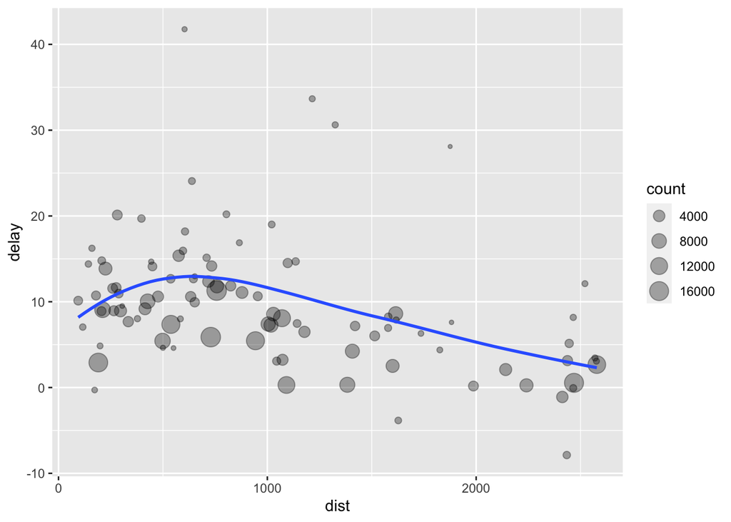

```r
delay <- filter(delay, count > 20, dest != "HNL")

# It looks like delays increase with distance up to ~750 miles
# and then decrease. Maybe as flights get longer there's more
# ability to make up delays in the air?
ggplot(data = delay, aes(x = dist, y = delay)) +
  geom_point(aes(size = count), alpha = 1/3) +
  geom_smooth(se = FALSE)
```

Start here

```r
names(delay)
```

```
## [1] "dest"  "count" "dist"  "delay"
```

```r
head(delay)
```

```
## # A tibble: 6 × 4
##   dest  count  dist delay
##   <chr> <int> <dbl> <dbl>
## 1 ABQ     254 1826   4.38
## 2 ACK     265  199   4.85
## 3 ALB     439  143  14.4
## 4 ATL   17215  757. 11.3
## 5 AUS    2439 1514.  6.02
## 6 AVL     275  584.  8.00
```

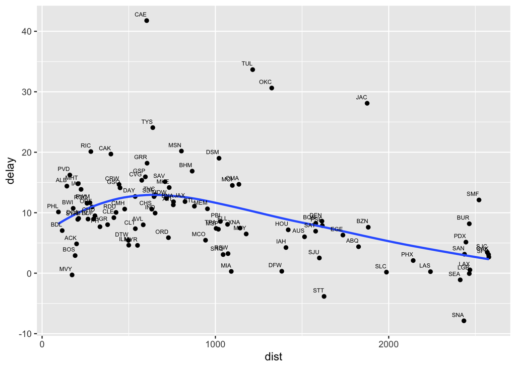

```r
ggplot(data = delay, aes(x = dist, y = delay, label=dest)) +
  geom_point() +
  geom_smooth(se = FALSE)+
  geom_text(size=2,aes(label=dest), hjust=1, vjust=-1)
```

5. **Ejercicios**:

Hacer los ejercicios en la sección 5.6.7 del libro en español

## El Pipe

- %>% “El pipe”

## Otras funciones: NA

- na.rm=TRUE
- !is.na() = is not NA, pq al frente tiene “!”

```r
no_cancelados <- vuelos %>%
  filter(!is.na(atraso_salida), !is.na(atraso_llegada))
no_cancelados
```

```
## # A tibble: 327,346 × 19
##     anio   mes   dia horario_salida salida_programada atraso_salida
##    <int> <int> <int>          <int>             <int>         <dbl>
##  1  2013     1     1            517               515             2
##  2  2013     1     1            533               529             4
##  3  2013     1     1            542               540             2
##  4  2013     1     1            544               545            -1
##  5  2013     1     1            554               600            -6
##  6  2013     1     1            554               558            -4
##  7  2013     1     1            555               600            -5
##  8  2013     1     1            557               600            -3
##  9  2013     1     1            557               600            -3
## 10  2013     1     1            558               600            -2
## # ℹ 327,336 more rows
## # ℹ 13 more variables: horario_llegada <int>, llegada_programada <int>,
## #   atraso_llegada <dbl>, aerolinea <chr>, vuelo <int>, codigo_cola <chr>,
## #   origen <chr>, destino <chr>, tiempo_vuelo <dbl>, distancia <dbl>,
## #   hora <dbl>, minuto <dbl>, fecha_hora <dttm>
```

```r
no_cancelados %>%
  group_by(anio, mes, dia) %>%
  summarise(mean = mean(atraso_salida))
```

```
## # A tibble: 365 × 4
## # Groups:   anio, mes [12]
##     anio   mes   dia  mean
##    <int> <int> <int> <dbl>
##  1  2013     1     1 11.4
##  2  2013     1     2 13.7
##  3  2013     1     3 10.9
##  4  2013     1     4  8.97
##  5  2013     1     5  5.73
##  6  2013     1     6  7.15
##  7  2013     1     7  5.42
##  8  2013     1     8  2.56
##  9  2013     1     9  2.30
## 10  2013     1    10  2.84
## # ℹ 355 more rows
```

```r
vuelos %>%
  group_by(anio, mes, dia) %>%
  summarise(mean = mean(atraso_salida, na.rm=TRUE))
```

```
## # A tibble: 365 × 4
## # Groups:   anio, mes [12]
##     anio   mes   dia  mean
##    <int> <int> <int> <dbl>
##  1  2013     1     1 11.5
##  2  2013     1     2 13.9
##  3  2013     1     3 11.0
##  4  2013     1     4  8.95
##  5  2013     1     5  5.73
##  6  2013     1     6  7.15
##  7  2013     1     7  5.42
##  8  2013     1     8  2.55
##  9  2013     1     9  2.28
## 10  2013     1    10  2.84
## # ℹ 355 more rows
```

```r
#,
#            max=max(atraso_salida,na.rm = TRUE),
#            n=n())
```

## Otras funciones:

Tarea de grupo.

Preparar un .rmd con la explicaciones de como utilizar la función mencionado abajo. Debe incluir

1. La definición de la función en palabra y matemática.
2. un script sencillo (con pocos datos) (uno o más ejemplos) para explicar la función
3. un script con los datos de “vuelos” o de “Covid-19 de PR”.
4. a las 2:20pm cada grupo presentará su trabajo.
5. Despues de la clase cada grupo, mejorará su .rmd con los comentarios recibidos.
6. Domingo se subirá el .rmd y el .html en Edmodo (cada estudiante lo subira: tendra el nombre de cada estudiante en el trabajo)
7. El profesor revisará los trabajos y subsiguiente se distribuira los .rmd y html a los estudiantes.
- IQR() ## G1
- mad() ## G2
- first() ## G3
- last() ## G3
- quantile() ## G4
- signif() ## G5
  - min()
- max()
- mean()
- sd() ***
1. **Ejercicios**:

Hacer los ejercicios en la sección 5.7.1 del libro en español

Rolling average:

https://stackoverflow.com/questions/743812/calculating-moving-average

```r
library(tidyverse)
library(zoo)
some_data = tibble(day = 1:10)
some_data
```

```
## # A tibble: 10 × 1
##      day
##    <int>
##  1     1
##  2     2
##  3     3
##  4     4
##  5     5
##  6     6
##  7     7
##  8     8
##  9     9
## 10    10
```

```r
# cma = centered moving average
# tma = trailing moving average
some_data %>%
    mutate(cma = rollmean(day, k = 3, fill = NA)) %>%
    mutate(tma = rollmean(day, k = 3, fill = NA, align = "right")) %>%
   mutate(lma = rollmean(day, k = 3, fill = NA, align = "left")) %>%
  mutate(cmax=rollmax(day, k=30, fill=NA))
```

```
## # A tibble: 10 × 5
##      day   cma   tma   lma cmax
##    <int> <dbl> <dbl> <dbl> <lgl>
##  1     1    NA    NA     2 NA
##  2     2     2    NA     3 NA
##  3     3     3     2     4 NA
##  4     4     4     3     5 NA
##  5     5     5     4     6 NA
##  6     6     6     5     7 NA
##  7     7     7     6     8 NA
##  8     8     8     7     9 NA
##  9     9     9     8    NA NA
## 10    10    NA     9    NA NA
```

```r
some_data
```

```
## # A tibble: 10 × 1
##      day
##    <int>
##  1     1
##  2     2
##  3     3
##  4     4
##  5     5
##  6     6
##  7     7
##  8     8
##  9     9
## 10    10
```

# Script

Fecha de la ultima revisión

```
## [1] "2023-08-09"
```

El tema proviene de los siguientes sitios.

English: https://r4ds.had.co.nz/workflow-scripts.html

Español: https://r4ds-en-espaniol.netlify.app/flujo-de-trabajo-scripts.html

**Temas super importante**:

## Scripts:

- Ejecutando códigos
- Diagnostico de Rstudio
1. **Ejercicios**:

Hacer los ejercicios en la sección 6.3 del libro en español

```r
library(dplyr)
library(datos)
library(nycflights13)

names(vuelos)
```

```
##  [1] "anio"               "mes"                "dia"
##  [4] "horario_salida"     "salida_programada"  "atraso_salida"
##  [7] "horario_llegada"    "llegada_programada" "atraso_llegada"
## [10] "aerolinea"          "vuelo"              "codigo_cola"
## [13] "origen"             "destino"            "tiempo_vuelo"
## [16] "distancia"          "hora"               "minuto"
## [19] "fecha_hora"
```

```r
no_cancelado <- vuelos %>%
  filter(!is.na(atraso_salida), !is.na(atraso_llegada))
head(no_cancelado)
```

```
## # A tibble: 6 × 19
##    anio   mes   dia horario_salida salida_programada atraso_salida
##   <int> <int> <int>          <int>             <int>         <dbl>
## 1  2013     1     1            517               515             2
## 2  2013     1     1            533               529             4
## 3  2013     1     1            542               540             2
## 4  2013     1     1            544               545            -1
## 5  2013     1     1            554               600            -6
## 6  2013     1     1            554               558            -4
## # ℹ 13 more variables: horario_llegada <int>, llegada_programada <int>,
## #   atraso_llegada <dbl>, aerolinea <chr>, vuelo <int>, codigo_cola <chr>,
## #   origen <chr>, destino <chr>, tiempo_vuelo <dbl>, distancia <dbl>,
## #   hora <dbl>, minuto <dbl>, fecha_hora <dttm>
```

```r
no_cancelado %>%
  group_by(anio, mes, dia) %>%
  summarise(media = mean(atraso_salida))
```

```
## # A tibble: 365 × 4
## # Groups:   anio, mes [12]
##     anio   mes   dia media
##    <int> <int> <int> <dbl>
##  1  2013     1     1 11.4
##  2  2013     1     2 13.7
##  3  2013     1     3 10.9
##  4  2013     1     4  8.97
##  5  2013     1     5  5.73
##  6  2013     1     6  7.15
##  7  2013     1     7  5.42
##  8  2013     1     8  2.56
##  9  2013     1     9  2.30
## 10  2013     1    10  2.84
## # ℹ 355 more rows
```

```r
x <- 10
```

# Analisis Exploratorio

Fecha de la ultima revisión

```
## [1] "2023-08-09"
```

El tema proviene de los siguientes sitios.

English: https://r4ds.had.co.nz/exploratory-data-analysis.html

Español: https://r4ds-en-espaniol.netlify.app/análisis-exploratorio-de-datos-eda.html

## Temas

- Variación
- Valores faltantes
- Covariación
- Patrones y modelos
- Argumentos en ggplot2

## Terminos importantes

- variable
- valor
- observación
- datos tabulados

### Variación

- visualización de las distribuciones
- count()
- cut_width()
- valores típicos
- valores inusuales o atípicos
1. **Ejercicios**:

Hacer los ejercicios en la sección 7.3.4 del libro en español

### Valores faltantes

- between()
- ifelse()
2. **Ejercicios**:

Hacer los ejercicios en la sección 7.4.1 del libro en español

### Covariación

- geom_boxplot
- IQR()
2. **Ejercicios**:

Hacer los ejercicios en la sección 7.5.1.1 del libro en español

### Dos variables categóricas

- geom_count()
- geom_tile()
2. **Ejercicios**:

Hacer los ejercicios en la sección 7.5.2.1 del libro en español

### Dos variables continuas

- geom_point()
- geom_hex()
- geopm_boxplot()
3. **Ejercicios**:

Hacer los ejercicios en la sección 7.5.3.1 del libro en español

### Patrones y modelos

- construir un modelo estádistico

# Pipes

Fecha de la ultima revisión

```
## [1] "2023-08-09"
```

El tema proviene de los siguientes sitios.

English: https://r4ds.had.co.nz/pipes.html

Español: https://es.r4ds.hadley.nz/pipes.html

## Temas: El paquete “magrittr”

- %>% pipes

## Alternativas a los pipes

- Pasos intermedios
- Sobre escribir el original

## Composición de funciones

## Otras herramientas de magrittr

- %T>%
- %$%

```r
library(magrittr)
iris %>%
  subset(Sepal.Length > mean(Sepal.Length)) %$%
  cor(Sepal.Length, Sepal.Width)
```

```
## [1] 0.3361992
```

- %<>%

```r
# Example 1
head(iris)
```

```
##   Sepal.Length Sepal.Width Petal.Length Petal.Width Species
## 1          5.1         3.5          1.4         0.2  setosa
## 2          4.9         3.0          1.4         0.2  setosa
## 3          4.7         3.2          1.3         0.2  setosa
## 4          4.6         3.1          1.5         0.2  setosa
## 5          5.0         3.6          1.4         0.2  setosa
## 6          5.4         3.9          1.7         0.4  setosa
```

```r
head(iris$Sepal.Length %<>% sqrt)
```

```
## [1] 2.258318 2.213594 2.167948 2.144761 2.236068 2.323790
```

```r
# Example 2
x <- rnorm(100)
head(x, n=10)
```

```
##  [1]  1.4404800 -0.7195761  0.6709784 -0.4219485  0.3782196 -1.6665864
##  [7] -0.5082030  0.4433822 -1.7993868 -0.6179521
```

```r
x %<>%
  abs %>%
  sort

head(x, 20)
```

```
##  [1] 0.03262862 0.05212281 0.06958002 0.11127638 0.13375663 0.14755503
##  [7] 0.15261108 0.16725385 0.18112962 0.18935937 0.19254623 0.20008289
## [13] 0.20439512 0.22376997 0.23962135 0.23978737 0.25172508 0.27016891
## [19] 0.29397608 0.29871206
```

- %in%

# Tibbles

Fecha de la ultima revisión

```
## [1] "2023-08-09"
```

El tema proviene de los siguientes sitios.

English: https://r4ds.had.co.nz/tibbles.html

Español: https://es.r4ds.hadley.nz/tibbles.html

## Temas: El paquete Tibble

- as_tibble()

## Crear un tibble

- tibble()

Crear un tibble con la siguiente información. Una columna que tiene los valores del 1 al 8 que se llama “secuencia”, una segunda columna que tiene los siguientes valores 23,26, 24,26,27, 11,20,21 que se llama edad y una tercera columna con la siguiente información, Jose, Maria, Carol, Moncho, Liz, Maria, Jorge, Miguel, que ser llama Nombre

```r
library(tidyverse)
library(datos)

tibble(
  secuencia = c(1:8),
  edad = c(23,26, 24,26,27, 11,20,21),
  nombre = c("Jose", "Maria", "Carol", "Moncho", "Liz", "Maria", "Jorge", "Miguel")
)
```

```
## # A tibble: 8 × 3
##   secuencia  edad nombre
##       <int> <dbl> <chr>
## 1         1    23 Jose
## 2         2    26 Maria
## 3         3    24 Carol
## 4         4    26 Moncho
## 5         5    27 Liz
## 6         6    11 Maria
## 7         7    20 Jorge
## 8         8    21 Miguel
```

## Crear un tribble

- tribble()

```r
tribble(
  ~secuencia, ~edad, ~nombre,
  1, 23, "Jose",
  2, 26, "Maria",
  3, 23, "Carol"


)
```

```
## # A tibble: 3 × 3
##   secuencia  edad nombre
##       <dbl> <dbl> <chr>
## 1         1    23 Jose
## 2         2    26 Maria
## 3         3    23 Carol
```

## tibble vs. data.frame

```r
tb = tibble(
  a = lubridate::now() + runif(1e2) * 86400,
  b = lubridate::today() + runif(1e2) * 30,
  c = 1:1e2,
  d = runif(1e2),
  e = sample(letters, 1e2, replace = TRUE)
)
tb
```

```
## # A tibble: 100 × 5
##    a                   b              c      d e
##    <dttm>              <date>     <int>  <dbl> <chr>
##  1 2023-08-10 05:09:20 2023-08-10     1 0.913  t
##  2 2023-08-10 11:44:04 2023-08-29     2 0.217  t
##  3 2023-08-10 03:06:21 2023-09-06     3 0.425  y
##  4 2023-08-10 15:03:22 2023-09-06     4 0.161  t
##  5 2023-08-09 22:23:32 2023-08-21     5 0.678  n
##  6 2023-08-10 10:29:01 2023-08-24     6 0.810  h
##  7 2023-08-10 13:02:00 2023-09-04     7 0.497  t
##  8 2023-08-10 00:27:08 2023-08-21     8 0.516  i
##  9 2023-08-09 22:53:23 2023-09-07     9 0.996  v
## 10 2023-08-10 11:39:18 2023-08-12    10 0.0142 c
## # ℹ 90 more rows
```

```r
tb %>%
  print(n = 4, width = Inf)
```

```
## # A tibble: 100 × 5
##   a                   b              c     d e
##   <dttm>              <date>     <int> <dbl> <chr>
## 1 2023-08-10 05:09:20 2023-08-10     1 0.913 t
## 2 2023-08-10 11:44:04 2023-08-29     2 0.217 t
## 3 2023-08-10 03:06:21 2023-09-06     3 0.425 y
## 4 2023-08-10 15:03:22 2023-09-06     4 0.161 t
## # ℹ 96 more rows
```

```r
lubridate::now()
```

```
## [1] "2023-08-09 15:41:49 AST"
```

```r
lubridate::today()
```

```
## [1] "2023-08-09"
```

```r
runif(1e2)
```

```
##   [1] 0.06720144 0.36344893 0.42365036 0.61475506 0.13936548 0.93696836
##   [7] 0.03185225 0.28970737 0.25422726 0.48572644 0.23999583 0.10968567
##  [13] 0.80816026 0.72804554 0.99721566 0.85109837 0.60583722 0.39452732
##  [19] 0.84653024 0.06181209 0.04182914 0.22874975 0.20963190 0.66751263
##  [25] 0.75720453 0.37027180 0.55732594 0.11904509 0.75488829 0.44716694
##  [31] 0.77440325 0.75736731 0.46816886 0.65682886 0.40436202 0.45010758
##  [37] 0.95037750 0.43859341 0.20537516 0.60805685 0.76690959 0.60179131
##  [43] 0.82813666 0.21015923 0.90528768 0.53337325 0.10662122 0.23461466
##  [49] 0.82823060 0.44399896 0.54078700 0.66394601 0.18726848 0.95124657
##  [55] 0.01071190 0.77913667 0.13255339 0.62893715 0.33552675 0.34363333
##  [61] 0.76936895 0.40415450 0.28062533 0.45209948 0.98241634 0.45981291
##  [67] 0.07658892 0.39805852 0.75732176 0.05105335 0.58293976 0.53860386
##  [73] 0.66004960 0.14786535 0.68011689 0.67685515 0.92514718 0.60086828
##  [79] 0.58092331 0.34538629 0.69711091 0.27840322 0.62858271 0.27873059
##  [85] 0.38065433 0.44702004 0.04749599 0.33417592 0.42050413 0.53688459
##  [91] 0.33881823 0.50414441 0.10050108 0.85142337 0.18656326 0.57900727
##  [97] 0.07105309 0.40590987 0.25904949 0.94449087
```

```r
head(vuelos)
```

```
## # A tibble: 6 × 19
##    anio   mes   dia horario_salida salida_programada atraso_salida
##   <int> <int> <int>          <int>             <int>         <dbl>
## 1  2013     1     1            517               515             2
## 2  2013     1     1            533               529             4
## 3  2013     1     1            542               540             2
## 4  2013     1     1            544               545            -1
## 5  2013     1     1            554               600            -6
## 6  2013     1     1            554               558            -4
## # ℹ 13 more variables: horario_llegada <int>, llegada_programada <int>,
## #   atraso_llegada <dbl>, aerolinea <chr>, vuelo <int>, codigo_cola <chr>,
## #   origen <chr>, destino <chr>, tiempo_vuelo <dbl>, distancia <dbl>,
## #   hora <dbl>, minuto <dbl>, fecha_hora <dttm>
```

```r
vuelos %>%
  print(n = 4, width = 2)
```

```
## # A
## #   tibble:
## #   336,776
## #   ×
## #   19
## # ℹ 336,772 more rows
## # ℹ 19 more variables: anio <int>, mes <int>, dia <int>, horario_salida <int>, salida_programada <int>, atraso_salida <dbl>, horario_llegada <int>, llegada_programada <int>, atraso_llegada <dbl>, aerolinea <chr>, vuelo <int>, codigo_cola <chr>, origen <chr>, destino <chr>, tiempo_vuelo <dbl>, dis…
```

```r
class(as.data.frame(tb))
```

```
## [1] "data.frame"
```

## Seleccion de subconjuntos

```r
head(vuelos$mes, n=5)
```

```
## [1] 1 1 1 1 1
```

```r
vuelos[["mes"]] |> head(n=40)
```

```
##  [1] 1 1 1 1 1 1 1 1 1 1 1 1 1 1 1 1 1 1 1 1 1 1 1 1 1 1 1 1 1 1 1 1 1 1 1 1 1 1
## [39] 1 1
```

```r
#Usar esta función dentro de pipe

vuelos %>% .$mes |> head(n=40)
```

```
##  [1] 1 1 1 1 1 1 1 1 1 1 1 1 1 1 1 1 1 1 1 1 1 1 1 1 1 1 1 1 1 1 1 1 1 1 1 1 1 1
## [39] 1 1
```

```r
vuelos %>% .[["mes"]] |> head(n=40)
```

```
##  [1] 1 1 1 1 1 1 1 1 1 1 1 1 1 1 1 1 1 1 1 1 1 1 1 1 1 1 1 1 1 1 1 1 1 1 1 1 1 1
## [39] 1 1
```

1. **Ejercicios**:

Hacer los ejercicios en la sección 10.5 del libro en español